June 6th, 2020

# TOURISM AND CULTURE

##### Group 15: Marco Battiston & two colleagues

The original source for our project is https://ec.europa.eu/eurostat.

The main dataset we picked provides information about European countries' mobility.

In our analysis, we carry out a **comparison between people's flows and their corresponding cultural levels**, exploiting a second dataset (concerning cultural investments) as input.

Our final goal is to figure out if culture can be described as an impactful factor on people's willingness to travel.

Datasets link: https://drive.google.com/drive/u/0/folders/1KIshNBH3PGpz5hb9glmhGYwLYZNEWhbh

1. **Most appealing countries**
   1. Data Loading
   2. Data Cleaning
   3. Data Reshaping
   4. Data Visualization
   5. Data Analysis
1. **Do cultural investments make a country appealing to tourists?**
   1. Data Loading
   2. Data Cleaning
   3. Data Reshaping
   4. Data Combining
   5. Data Visualization
   6. Data Analysis
1. **Do higher cultural levels result in higher mobility?**
   1. Flows Dataset
      1. Data Loading
      2. Data Cleaning
      3. Data Reshaping
   2. Population Dataset
      1. Data Loading
      2. Data Cleaning
      3. Data Reshaping
   3. Data Combining
   4. Data Visualization
   5. Data Analysis
1. **Do efficient transport systems correspond to higher in/out tourist flows?**
   1. Passengers Dataset
      1. Data Loading
      2. Data Cleaning
      3. Data Reshaping
   2. Government expenses on transport
      1. Data Loading
      2. Data Cleaning
      3. Data Reshaping
   3. Data Combining
   4. Data Visualization
   5. Data Analysis
1. **Interactive part**

###### RESEARCH QUESTIONS:

1. What are the most appealing countries? Where do tourists prefer to go?
2. How do investments in culture affect european countries’ mobility?
   1. Are cultural investments effective in making a country appealing to tourists?
   2. Do higher cultural levels result in higher mobility? Are european citizens more stimulated to visit other countries?
3. Do efficient transport systems correspond to higher in/out tourist flows?

```python
import numpy as np
import pandas as pd
import seaborn as sns
import matplotlib.pyplot as plt
```

[output not shown]

# QUESTION 1

**STEP TO ANSWER QUESTION 1:**

```
1. Upload dataset "flows.csv"
2. Drop useless rows and columns
3. Sort by TIME, GEO and take the sum of EXTRA-EU and INTRA-EU (we need the aggregate)
4. Rank from most appealing to least appealing per year
5. Take the most appealing of each year with a slicing
6. Visualize results and analyze them
```

## Data loading

First of all, we open the Eurostat dataset and we have a look at its structure.

```python
# opening the Eurostat csv file concerning in/out-flows of European citizens:
euflows_df = pd.read_csv('flows.csv')
euflows_df
```

|  | TIME | GEO | UNIT | TRA_MEAS | PARTNER | Value | Flag and Footnotes |
| --- | --- | --- | --- | --- | --- | --- | --- |
| 0 | 2000 | European Union - 27 countries (from 2020) | Passenger | Passengers on board | Extra-EU | : | NaN |
| 1 | 2000 | European Union - 27 countries (from 2020) | Passenger | Passengers on board | Other european countries (aggregate changing a... | : | NaN |
| 2 | 2000 | European Union - 27 countries (from 2020) | Passenger | Passengers on board (arrivals) | Extra-EU | : | NaN |
| 3 | 2000 | European Union - 27 countries (from 2020) | Passenger | Passengers on board (arrivals) | Other european countries (aggregate changing a... | : | NaN |
| 4 | 2000 | European Union - 27 countries (from 2020) | Passenger | Passengers on board (departures) | Extra-EU | : | NaN |
| ... | ... | ... | ... | ... | ... | ... | ... |
| 3415 | 2018 | United Kingdom | Passenger | Passengers on board | Other european countries (aggregate changing a... | 16,905,534 | NaN |
| 3416 | 2018 | United Kingdom | Passenger | Passengers on board (arrivals) | Extra-EU | 40,896,187 | NaN |
| 3417 | 2018 | United Kingdom | Passenger | Passengers on board (arrivals) | Other european countries (aggregate changing a... | 8,473,108 | NaN |
| 3418 | 2018 | United Kingdom | Passenger | Passengers on board (departures) | Extra-EU | 40,250,218 | NaN |
| 3419 | 2018 | United Kingdom | Passenger | Passengers on board (departures) | Other european countries (aggregate changing a... | 8,432,426 | NaN |

3420 rows × 7 columns

```python
euflows_df.columns
```

```
Index(['TIME', 'GEO', 'UNIT', 'TRA_MEAS', 'PARTNER', 'Value',
       'Flag and Footnotes'],
      dtype='object')
```

We observe that the dataset contains aggregate information concerning the whole European Union.

Since we aim to compare different countries, we do not need those aggregate entries and we decide to remove them. Thus, we perform some cleansing.

## Data cleaning

```python
# we extrapolate the index linked to aggregate data
index_to_drop = euflows_df.loc[(euflows_df['GEO']=='European Union - 27 countries (from 2020)') |
                                (euflows_df['GEO']=='European Union - 28 countries (2013-2020)')]
index_to_drop.index
```

```
Int64Index([   0,    1,    2,    3,    4,    5,    6,    7,    8,    9,
            ...
            3242, 3243, 3244, 3245, 3246, 3247, 3248, 3249, 3250, 3251],
           dtype='int64', length=228)
```

```python
# and we remove the rows containing aggregate data, through the corresponding index
droprows_df = euflows_df.drop(euflows_df.index[index_to_drop.index])
droprows_df
```

|  | TIME | GEO | UNIT | TRA_MEAS | PARTNER | Value | Flag and Footnotes |
| --- | --- | --- | --- | --- | --- | --- | --- |
| 12 | 2000 | Belgium | Passenger | Passengers on board | Extra-EU | : | NaN |
| 13 | 2000 | Belgium | Passenger | Passengers on board | Other european countries (aggregate changing a... | : | NaN |
| 14 | 2000 | Belgium | Passenger | Passengers on board (arrivals) | Extra-EU | : | NaN |
| 15 | 2000 | Belgium | Passenger | Passengers on board (arrivals) | Other european countries (aggregate changing a... | : | NaN |
| 16 | 2000 | Belgium | Passenger | Passengers on board (departures) | Extra-EU | : | NaN |
| ... | ... | ... | ... | ... | ... | ... | ... |
| 3415 | 2018 | United Kingdom | Passenger | Passengers on board | Other european countries (aggregate changing a... | 16,905,534 | NaN |
| 3416 | 2018 | United Kingdom | Passenger | Passengers on board (arrivals) | Extra-EU | 40,896,187 | NaN |
| 3417 | 2018 | United Kingdom | Passenger | Passengers on board (arrivals) | Other european countries (aggregate changing a... | 8,473,108 | NaN |
| 3418 | 2018 | United Kingdom | Passenger | Passengers on board (departures) | Extra-EU | 40,250,218 | NaN |
| 3419 | 2018 | United Kingdom | Passenger | Passengers on board (departures) | Other european countries (aggregate changing a... | 8,432,426 | NaN |

3192 rows × 7 columns

We fix some issues concerning the entries of 'Value' column.

```python
# We want to aggregate EXTRA-EU and INTRA-EU data, since we aim at a global-view.
# So we want to take the sum between EXTRA-EU and INTRA-EU for each variable
# Our variables are: 'TIME', 'GEO' and type of 'TRA_MEAS'
# To do so, we have to perform the 'sum' method applied to the 'groupby' method

# The problem is the following:
# the 'sum' method needs integers values as inputs
# instead, our pandas.Series related to the variable 'Value' is made up of strings
# thus, we have to turn those strings into integers

# To delete commas separator we use replace

droprows_df.Value = droprows_df.Value.str.replace(',', '')

# Also, we need to replace ":" with 0 since the former is not recognized by the program

droprows_df = droprows_df.replace(to_replace=":",value="0")

# Now we want to convert the cleaned strings into integers, and we can do this with 2 methods:
# first method is: "to-numeric"
# second method is: "astype(int)"

droprows_df['Value'] = pd.to_numeric(droprows_df['Value'])
```

Before proceeding, we remove the useless columns.

```python
dropcols_df = droprows_df[['TIME','GEO','TRA_MEAS','PARTNER','Value']]
dropcols_df
```

|  | TIME | GEO | TRA_MEAS | PARTNER | Value |
| --- | --- | --- | --- | --- | --- |
| 12 | 2000 | Belgium | Passengers on board | Extra-EU | 0 |
| 13 | 2000 | Belgium | Passengers on board | Other european countries (aggregate changing a... | 0 |
| 14 | 2000 | Belgium | Passengers on board (arrivals) | Extra-EU | 0 |
| 15 | 2000 | Belgium | Passengers on board (arrivals) | Other european countries (aggregate changing a... | 0 |
| 16 | 2000 | Belgium | Passengers on board (departures) | Extra-EU | 0 |
| ... | ... | ... | ... | ... | ... |
| 3415 | 2018 | United Kingdom | Passengers on board | Other european countries (aggregate changing a... | 16905534 |
| 3416 | 2018 | United Kingdom | Passengers on board (arrivals) | Extra-EU | 40896187 |
| 3417 | 2018 | United Kingdom | Passengers on board (arrivals) | Other european countries (aggregate changing a... | 8473108 |
| 3418 | 2018 | United Kingdom | Passengers on board (departures) | Extra-EU | 40250218 |
| 3419 | 2018 | United Kingdom | Passengers on board (departures) | Other european countries (aggregate changing a... | 8432426 |

3192 rows × 5 columns

And we only keep the rows of our interest.

```python
arrivals_df = dropcols_df[dropcols_df.TRA_MEAS == 'Passengers on board (arrivals)' ]
arrivals_df
```

|  | TIME | GEO | TRA_MEAS | PARTNER | Value |
| --- | --- | --- | --- | --- | --- |
| 14 | 2000 | Belgium | Passengers on board (arrivals) | Extra-EU | 0 |
| 15 | 2000 | Belgium | Passengers on board (arrivals) | Other european countries (aggregate changing a... | 0 |
| 20 | 2000 | Bulgaria | Passengers on board (arrivals) | Extra-EU | 0 |
| 21 | 2000 | Bulgaria | Passengers on board (arrivals) | Other european countries (aggregate changing a... | 0 |
| 26 | 2000 | Czechia | Passengers on board (arrivals) | Extra-EU | 0 |
| ... | ... | ... | ... | ... | ... |
| 3405 | 2018 | Finland | Passengers on board (arrivals) | Other european countries (aggregate changing a... | 1486575 |
| 3410 | 2018 | Sweden | Passengers on board (arrivals) | Extra-EU | 5219092 |
| 3411 | 2018 | Sweden | Passengers on board (arrivals) | Other european countries (aggregate changing a... | 3612206 |
| 3416 | 2018 | United Kingdom | Passengers on board (arrivals) | Extra-EU | 40896187 |
| 3417 | 2018 | United Kingdom | Passengers on board (arrivals) | Other european countries (aggregate changing a... | 8473108 |

1064 rows × 5 columns

## Data reshaping

We notice that our dataset distinguishes travellers going to other European countries and travellers going out of EU. Actually, we are not interested in this differentiation. Therefore, we need to compact those entries.

```python
inflows_df = arrivals_df.groupby(by=['TIME','GEO','TRA_MEAS'], as_index=False).sum()
inflows_df
```

|  | TIME | GEO | TRA_MEAS | Value |
| --- | --- | --- | --- | --- |
| 0 | 2000 | Austria | Passengers on board (arrivals) | 3438464 |
| 1 | 2000 | Belgium | Passengers on board (arrivals) | 0 |
| 2 | 2000 | Bulgaria | Passengers on board (arrivals) | 0 |
| 3 | 2000 | Croatia | Passengers on board (arrivals) | 0 |
| 4 | 2000 | Cyprus | Passengers on board (arrivals) | 0 |
| ... | ... | ... | ... | ... |
| 527 | 2018 | Slovakia | Passengers on board (arrivals) | 1198661 |
| 528 | 2018 | Slovenia | Passengers on board (arrivals) | 890968 |
| 529 | 2018 | Spain | Passengers on board (arrivals) | 65092414 |
| 530 | 2018 | Sweden | Passengers on board (arrivals) | 8831298 |
| 531 | 2018 | United Kingdom | Passengers on board (arrivals) | 49369295 |

532 rows × 4 columns

We modify the aggregate-data column entries. Then, we change a label name.

```python
inflows_df['PARTNER']='Worldwide'
inflows_df = inflows_df.rename(columns={'TRA_MEAS': 'TYPE OF FLOW'})
inflows_df

# inflows = former flows4
```

|  | TIME | GEO | TYPE OF FLOW | Value | PARTNER |
| --- | --- | --- | --- | --- | --- |
| 0 | 2000 | Austria | Passengers on board (arrivals) | 3438464 | Worldwide |
| 1 | 2000 | Belgium | Passengers on board (arrivals) | 0 | Worldwide |
| 2 | 2000 | Bulgaria | Passengers on board (arrivals) | 0 | Worldwide |
| 3 | 2000 | Croatia | Passengers on board (arrivals) | 0 | Worldwide |
| 4 | 2000 | Cyprus | Passengers on board (arrivals) | 0 | Worldwide |
| ... | ... | ... | ... | ... | ... |
| 527 | 2018 | Slovakia | Passengers on board (arrivals) | 1198661 | Worldwide |
| 528 | 2018 | Slovenia | Passengers on board (arrivals) | 890968 | Worldwide |
| 529 | 2018 | Spain | Passengers on board (arrivals) | 65092414 | Worldwide |
| 530 | 2018 | Sweden | Passengers on board (arrivals) | 8831298 | Worldwide |
| 531 | 2018 | United Kingdom | Passengers on board (arrivals) | 49369295 | Worldwide |

532 rows × 5 columns

We create a new column in our dataset and we fill it with a ranking of the countries based on their corresponding in-flow level. Also, we establish a differentiation per year.

```python
inranked_df = inflows_df.sort_values(by=['TIME','Value'], ascending=False, inplace=False)

# To create a new column with the ranking x year we use a numpy array
# the array consists of numbers from 1 to 28
# and we repeat the array 19 times (since our data concern 19 years, from 2000 to 2018)

test = np.arange(1,29)
result = np.repeat(test[np.newaxis,...], 19, axis=0)
result = result.tolist()
flattened = [val for sublist in result for val in sublist]
flattened

inranked_df['RANKING'] = flattened

inranked_df

# inranked = former flows 5
```

|  | TIME | GEO | TYPE OF FLOW | Value | PARTNER | RANKING |
| --- | --- | --- | --- | --- | --- | --- |
| 514 | 2018 | Germany (until 1990 former territory of the FRG) | Passengers on board (arrivals) | 66754812 | Worldwide | 1 |
| 529 | 2018 | Spain | Passengers on board (arrivals) | 65092414 | Worldwide | 2 |
| 531 | 2018 | United Kingdom | Passengers on board (arrivals) | 49369295 | Worldwide | 3 |
| 513 | 2018 | France | Passengers on board (arrivals) | 45887748 | Worldwide | 4 |
| 518 | 2018 | Italy | Passengers on board (arrivals) | 34955833 | Worldwide | 5 |
| ... | ... | ... | ... | ... | ... | ... |
| 21 | 2000 | Portugal | Passengers on board (arrivals) | 0 | Worldwide | 24 |
| 22 | 2000 | Romania | Passengers on board (arrivals) | 0 | Worldwide | 25 |
| 23 | 2000 | Slovakia | Passengers on board (arrivals) | 0 | Worldwide | 26 |
| 24 | 2000 | Slovenia | Passengers on board (arrivals) | 0 | Worldwide | 27 |
| 25 | 2000 | Spain | Passengers on board (arrivals) | 0 | Worldwide | 28 |

532 rows × 6 columns

```python
# Creating a new dataset that can be useful for later

xflows_df = inflows_df
xflows_df['ARR_RANKING'] = inranked_df['RANKING']
xflows_df['ARRIVALS'] = inranked_df['Value']
yflows_df = xflows_df[['ARR_RANKING', 'ARRIVALS']]
xflows_df
```

|  | TIME | GEO | TYPE OF FLOW | Value | PARTNER | ARR_RANKING | ARRIVALS |
| --- | --- | --- | --- | --- | --- | --- | --- |
| 0 | 2000 | Austria | Passengers on board (arrivals) | 3438464 | Worldwide | 4 | 3438464 |
| 1 | 2000 | Belgium | Passengers on board (arrivals) | 0 | Worldwide | 8 | 0 |
| 2 | 2000 | Bulgaria | Passengers on board (arrivals) | 0 | Worldwide | 9 | 0 |
| 3 | 2000 | Croatia | Passengers on board (arrivals) | 0 | Worldwide | 10 | 0 |
| 4 | 2000 | Cyprus | Passengers on board (arrivals) | 0 | Worldwide | 11 | 0 |
| ... | ... | ... | ... | ... | ... | ... | ... |
| 527 | 2018 | Slovakia | Passengers on board (arrivals) | 1198661 | Worldwide | 25 | 1198661 |
| 528 | 2018 | Slovenia | Passengers on board (arrivals) | 890968 | Worldwide | 26 | 890968 |
| 529 | 2018 | Spain | Passengers on board (arrivals) | 65092414 | Worldwide | 2 | 65092414 |
| 530 | 2018 | Sweden | Passengers on board (arrivals) | 8831298 | Worldwide | 13 | 8831298 |
| 531 | 2018 | United Kingdom | Passengers on board (arrivals) | 49369295 | Worldwide | 3 | 49369295 |

532 rows × 7 columns

Before going on, we reset the index.

```python
flows_df = inranked_df.reset_index()
flows_df

# flows = former flows6
```

|  | index | TIME | GEO | TYPE OF FLOW | Value | PARTNER | RANKING |
| --- | --- | --- | --- | --- | --- | --- | --- |
| 0 | 514 | 2018 | Germany (until 1990 former territory of the FRG) | Passengers on board (arrivals) | 66754812 | Worldwide | 1 |
| 1 | 529 | 2018 | Spain | Passengers on board (arrivals) | 65092414 | Worldwide | 2 |
| 2 | 531 | 2018 | United Kingdom | Passengers on board (arrivals) | 49369295 | Worldwide | 3 |
| 3 | 513 | 2018 | France | Passengers on board (arrivals) | 45887748 | Worldwide | 4 |
| 4 | 518 | 2018 | Italy | Passengers on board (arrivals) | 34955833 | Worldwide | 5 |
| ... | ... | ... | ... | ... | ... | ... | ... |
| 527 | 21 | 2000 | Portugal | Passengers on board (arrivals) | 0 | Worldwide | 24 |
| 528 | 22 | 2000 | Romania | Passengers on board (arrivals) | 0 | Worldwide | 25 |
| 529 | 23 | 2000 | Slovakia | Passengers on board (arrivals) | 0 | Worldwide | 26 |
| 530 | 24 | 2000 | Slovenia | Passengers on board (arrivals) | 0 | Worldwide | 27 |
| 531 | 25 | 2000 | Spain | Passengers on board (arrivals) | 0 | Worldwide | 28 |

532 rows × 7 columns

We cleaned the original dataframe and we sorted the values it contains. The final output includes the ranking that we can use to answer our first question.

We can extrapolate the countries ranked in first position for each year.

```python
best1countries = flows_df[::28]
best1countries = best1countries.rename(columns={'TIME': 'TIME_FLOWS'})
best1countries = best1countries.rename(columns={'GEO': 'GEO_FLOWS'})
best1countries
```

|  | index | TIME_FLOWS | GEO_FLOWS | TYPE OF FLOW | Value | PARTNER | RANKING |
| --- | --- | --- | --- | --- | --- | --- | --- |
| 0 | 514 | 2018 | Germany (until 1990 former territory of the FRG) | Passengers on board (arrivals) | 66754812 | Worldwide | 1 |
| 28 | 501 | 2017 | Spain | Passengers on board (arrivals) | 65201921 | Worldwide | 1 |
| 56 | 473 | 2016 | Spain | Passengers on board (arrivals) | 60132618 | Worldwide | 1 |
| 84 | 430 | 2015 | Germany (until 1990 former territory of the FRG) | Passengers on board (arrivals) | 60317732 | Worldwide | 1 |
| 112 | 402 | 2014 | Germany (until 1990 former territory of the FRG) | Passengers on board (arrivals) | 57702895 | Worldwide | 1 |
| 140 | 374 | 2013 | Germany (until 1990 former territory of the FRG) | Passengers on board (arrivals) | 56440458 | Worldwide | 1 |
| 168 | 346 | 2012 | Germany (until 1990 former territory of the FRG) | Passengers on board (arrivals) | 55929102 | Worldwide | 1 |
| 196 | 318 | 2011 | Germany (until 1990 former territory of the FRG) | Passengers on board (arrivals) | 53827069 | Worldwide | 1 |
| 224 | 290 | 2010 | Germany (until 1990 former territory of the FRG) | Passengers on board (arrivals) | 50930552 | Worldwide | 1 |
| 252 | 262 | 2009 | Germany (until 1990 former territory of the FRG) | Passengers on board (arrivals) | 46990471 | Worldwide | 1 |
| 280 | 234 | 2008 | Germany (until 1990 former territory of the FRG) | Passengers on board (arrivals) | 48069498 | Worldwide | 1 |
| 308 | 206 | 2007 | Germany (until 1990 former territory of the FRG) | Passengers on board (arrivals) | 47361790 | Worldwide | 1 |
| 336 | 193 | 2006 | Spain | Passengers on board (arrivals) | 45145277 | Worldwide | 1 |
| 364 | 165 | 2005 | Spain | Passengers on board (arrivals) | 43576413 | Worldwide | 1 |
| 392 | 137 | 2004 | Spain | Passengers on board (arrivals) | 41617274 | Worldwide | 1 |
| 420 | 109 | 2003 | Spain | Passengers on board (arrivals) | 39351351 | Worldwide | 1 |
| 448 | 83 | 2002 | United Kingdom | Passengers on board (arrivals) | 28466591 | Worldwide | 1 |
| 476 | 55 | 2001 | United Kingdom | Passengers on board (arrivals) | 28254828 | Worldwide | 1 |
| 504 | 27 | 2000 | United Kingdom | Passengers on board (arrivals) | 29850093 | Worldwide | 1 |

We decide to focus on each year podium, i.e. on the countries ranked in first, second and third position for each year.

```python
firstcpery = flows_df[::28]
secondcpery = flows_df[1::28]
thirdcpery = flows_df[2::28]
best3countries = firstcpery.append(secondcpery).append(thirdcpery)
best3countries
```

|  | index | TIME | GEO | TYPE OF FLOW | Value | PARTNER | RANKING |
| --- | --- | --- | --- | --- | --- | --- | --- |
| 0 | 514 | 2018 | Germany (until 1990 former territory of the FRG) | Passengers on board (arrivals) | 66754812 | Worldwide | 1 |
| 28 | 501 | 2017 | Spain | Passengers on board (arrivals) | 65201921 | Worldwide | 1 |
| 56 | 473 | 2016 | Spain | Passengers on board (arrivals) | 60132618 | Worldwide | 1 |
| 84 | 430 | 2015 | Germany (until 1990 former territory of the FRG) | Passengers on board (arrivals) | 60317732 | Worldwide | 1 |
| 112 | 402 | 2014 | Germany (until 1990 former territory of the FRG) | Passengers on board (arrivals) | 57702895 | Worldwide | 1 |
| 140 | 374 | 2013 | Germany (until 1990 former territory of the FRG) | Passengers on board (arrivals) | 56440458 | Worldwide | 1 |
| 168 | 346 | 2012 | Germany (until 1990 former territory of the FRG) | Passengers on board (arrivals) | 55929102 | Worldwide | 1 |
| 196 | 318 | 2011 | Germany (until 1990 former territory of the FRG) | Passengers on board (arrivals) | 53827069 | Worldwide | 1 |
| 224 | 290 | 2010 | Germany (until 1990 former territory of the FRG) | Passengers on board (arrivals) | 50930552 | Worldwide | 1 |
| 252 | 262 | 2009 | Germany (until 1990 former territory of the FRG) | Passengers on board (arrivals) | 46990471 | Worldwide | 1 |
| 280 | 234 | 2008 | Germany (until 1990 former territory of the FRG) | Passengers on board (arrivals) | 48069498 | Worldwide | 1 |
| 308 | 206 | 2007 | Germany (until 1990 former territory of the FRG) | Passengers on board (arrivals) | 47361790 | Worldwide | 1 |
| 336 | 193 | 2006 | Spain | Passengers on board (arrivals) | 45145277 | Worldwide | 1 |
| 364 | 165 | 2005 | Spain | Passengers on board (arrivals) | 43576413 | Worldwide | 1 |
| 392 | 137 | 2004 | Spain | Passengers on board (arrivals) | 41617274 | Worldwide | 1 |
| 420 | 109 | 2003 | Spain | Passengers on board (arrivals) | 39351351 | Worldwide | 1 |
| 448 | 83 | 2002 | United Kingdom | Passengers on board (arrivals) | 28466591 | Worldwide | 1 |
| 476 | 55 | 2001 | United Kingdom | Passengers on board (arrivals) | 28254828 | Worldwide | 1 |
| 504 | 27 | 2000 | United Kingdom | Passengers on board (arrivals) | 29850093 | Worldwide | 1 |
| 1 | 529 | 2018 | Spain | Passengers on board (arrivals) | 65092414 | Worldwide | 2 |
| 29 | 486 | 2017 | Germany (until 1990 former territory of the FRG) | Passengers on board (arrivals) | 62382409 | Worldwide | 2 |
| 57 | 458 | 2016 | Germany (until 1990 former territory of the FRG) | Passengers on board (arrivals) | 59199685 | Worldwide | 2 |
| 85 | 445 | 2015 | Spain | Passengers on board (arrivals) | 53145901 | Worldwide | 2 |
| 113 | 417 | 2014 | Spain | Passengers on board (arrivals) | 51400420 | Worldwide | 2 |
| 141 | 389 | 2013 | Spain | Passengers on board (arrivals) | 50001381 | Worldwide | 2 |
| 169 | 361 | 2012 | Spain | Passengers on board (arrivals) | 47589665 | Worldwide | 2 |
| 197 | 333 | 2011 | Spain | Passengers on board (arrivals) | 47266251 | Worldwide | 2 |
| 225 | 305 | 2010 | Spain | Passengers on board (arrivals) | 42873511 | Worldwide | 2 |
| 253 | 277 | 2009 | Spain | Passengers on board (arrivals) | 42968923 | Worldwide | 2 |
| 281 | 249 | 2008 | Spain | Passengers on board (arrivals) | 48043944 | Worldwide | 2 |
| 309 | 221 | 2007 | Spain | Passengers on board (arrivals) | 47248038 | Worldwide | 2 |
| 337 | 178 | 2006 | Germany (until 1990 former territory of the FRG) | Passengers on board (arrivals) | 44311526 | Worldwide | 2 |
| 365 | 150 | 2005 | Germany (until 1990 former territory of the FRG) | Passengers on board (arrivals) | 43308289 | Worldwide | 2 |
| 393 | 122 | 2004 | Germany (until 1990 former territory of the FRG) | Passengers on board (arrivals) | 40557923 | Worldwide | 2 |
| 421 | 94 | 2003 | Germany (until 1990 former territory of the FRG) | Passengers on board (arrivals) | 34908063 | Worldwide | 2 |
| 449 | 66 | 2002 | Germany (until 1990 former territory of the FRG) | Passengers on board (arrivals) | 25972974 | Worldwide | 2 |
| 477 | 38 | 2001 | Germany (until 1990 former territory of the FRG) | Passengers on board (arrivals) | 26037572 | Worldwide | 2 |
| 505 | 10 | 2000 | Germany (until 1990 former territory of the FRG) | Passengers on board (arrivals) | 25488520 | Worldwide | 2 |
| 2 | 531 | 2018 | United Kingdom | Passengers on board (arrivals) | 49369295 | Worldwide | 3 |
| 30 | 503 | 2017 | United Kingdom | Passengers on board (arrivals) | 46114391 | Worldwide | 3 |
| 58 | 475 | 2016 | United Kingdom | Passengers on board (arrivals) | 43922344 | Worldwide | 3 |
| 86 | 447 | 2015 | United Kingdom | Passengers on board (arrivals) | 43720027 | Worldwide | 3 |
| 114 | 419 | 2014 | United Kingdom | Passengers on board (arrivals) | 42867007 | Worldwide | 3 |
| 142 | 391 | 2013 | United Kingdom | Passengers on board (arrivals) | 41569865 | Worldwide | 3 |
| 170 | 363 | 2012 | United Kingdom | Passengers on board (arrivals) | 39937215 | Worldwide | 3 |
| 198 | 335 | 2011 | United Kingdom | Passengers on board (arrivals) | 39643127 | Worldwide | 3 |
| 226 | 307 | 2010 | United Kingdom | Passengers on board (arrivals) | 38780292 | Worldwide | 3 |
| 254 | 279 | 2009 | United Kingdom | Passengers on board (arrivals) | 38115455 | Worldwide | 3 |
| 282 | 251 | 2008 | United Kingdom | Passengers on board (arrivals) | 38853023 | Worldwide | 3 |
| 310 | 223 | 2007 | United Kingdom | Passengers on board (arrivals) | 38528286 | Worldwide | 3 |
| 338 | 195 | 2006 | United Kingdom | Passengers on board (arrivals) | 36709655 | Worldwide | 3 |
| 366 | 167 | 2005 | United Kingdom | Passengers on board (arrivals) | 35101624 | Worldwide | 3 |
| 394 | 139 | 2004 | United Kingdom | Passengers on board (arrivals) | 32428102 | Worldwide | 3 |
| 422 | 111 | 2003 | United Kingdom | Passengers on board (arrivals) | 28871661 | Worldwide | 3 |
| 450 | 65 | 2002 | France | Passengers on board (arrivals) | 17722110 | Worldwide | 3 |
| 478 | 47 | 2001 | Netherlands | Passengers on board (arrivals) | 9922555 | Worldwide | 3 |
| 506 | 14 | 2000 | Italy | Passengers on board (arrivals) | 8140632 | Worldwide | 3 |

We sort the index to reorder the result in a more meaningful way. Finally, we want to obtain all years podia, listed one after the other.

```python
podium_py = best3countries.sort_index()
podium_py = podium_py.rename(columns={'TIME': 'TIME_FLOWS'})
podium_py

# podium_py is former best3countries1
```

|  | index | TIME_FLOWS | GEO | TYPE OF FLOW | Value | PARTNER | RANKING |
| --- | --- | --- | --- | --- | --- | --- | --- |
| 0 | 514 | 2018 | Germany (until 1990 former territory of the FRG) | Passengers on board (arrivals) | 66754812 | Worldwide | 1 |
| 1 | 529 | 2018 | Spain | Passengers on board (arrivals) | 65092414 | Worldwide | 2 |
| 2 | 531 | 2018 | United Kingdom | Passengers on board (arrivals) | 49369295 | Worldwide | 3 |
| 28 | 501 | 2017 | Spain | Passengers on board (arrivals) | 65201921 | Worldwide | 1 |
| 29 | 486 | 2017 | Germany (until 1990 former territory of the FRG) | Passengers on board (arrivals) | 62382409 | Worldwide | 2 |
| 30 | 503 | 2017 | United Kingdom | Passengers on board (arrivals) | 46114391 | Worldwide | 3 |
| 56 | 473 | 2016 | Spain | Passengers on board (arrivals) | 60132618 | Worldwide | 1 |
| 57 | 458 | 2016 | Germany (until 1990 former territory of the FRG) | Passengers on board (arrivals) | 59199685 | Worldwide | 2 |
| 58 | 475 | 2016 | United Kingdom | Passengers on board (arrivals) | 43922344 | Worldwide | 3 |
| 84 | 430 | 2015 | Germany (until 1990 former territory of the FRG) | Passengers on board (arrivals) | 60317732 | Worldwide | 1 |
| 85 | 445 | 2015 | Spain | Passengers on board (arrivals) | 53145901 | Worldwide | 2 |
| 86 | 447 | 2015 | United Kingdom | Passengers on board (arrivals) | 43720027 | Worldwide | 3 |
| 112 | 402 | 2014 | Germany (until 1990 former territory of the FRG) | Passengers on board (arrivals) | 57702895 | Worldwide | 1 |
| 113 | 417 | 2014 | Spain | Passengers on board (arrivals) | 51400420 | Worldwide | 2 |
| 114 | 419 | 2014 | United Kingdom | Passengers on board (arrivals) | 42867007 | Worldwide | 3 |
| 140 | 374 | 2013 | Germany (until 1990 former territory of the FRG) | Passengers on board (arrivals) | 56440458 | Worldwide | 1 |
| 141 | 389 | 2013 | Spain | Passengers on board (arrivals) | 50001381 | Worldwide | 2 |
| 142 | 391 | 2013 | United Kingdom | Passengers on board (arrivals) | 41569865 | Worldwide | 3 |
| 168 | 346 | 2012 | Germany (until 1990 former territory of the FRG) | Passengers on board (arrivals) | 55929102 | Worldwide | 1 |
| 169 | 361 | 2012 | Spain | Passengers on board (arrivals) | 47589665 | Worldwide | 2 |
| 170 | 363 | 2012 | United Kingdom | Passengers on board (arrivals) | 39937215 | Worldwide | 3 |
| 196 | 318 | 2011 | Germany (until 1990 former territory of the FRG) | Passengers on board (arrivals) | 53827069 | Worldwide | 1 |
| 197 | 333 | 2011 | Spain | Passengers on board (arrivals) | 47266251 | Worldwide | 2 |
| 198 | 335 | 2011 | United Kingdom | Passengers on board (arrivals) | 39643127 | Worldwide | 3 |
| 224 | 290 | 2010 | Germany (until 1990 former territory of the FRG) | Passengers on board (arrivals) | 50930552 | Worldwide | 1 |
| 225 | 305 | 2010 | Spain | Passengers on board (arrivals) | 42873511 | Worldwide | 2 |
| 226 | 307 | 2010 | United Kingdom | Passengers on board (arrivals) | 38780292 | Worldwide | 3 |
| 252 | 262 | 2009 | Germany (until 1990 former territory of the FRG) | Passengers on board (arrivals) | 46990471 | Worldwide | 1 |
| 253 | 277 | 2009 | Spain | Passengers on board (arrivals) | 42968923 | Worldwide | 2 |
| 254 | 279 | 2009 | United Kingdom | Passengers on board (arrivals) | 38115455 | Worldwide | 3 |
| 280 | 234 | 2008 | Germany (until 1990 former territory of the FRG) | Passengers on board (arrivals) | 48069498 | Worldwide | 1 |
| 281 | 249 | 2008 | Spain | Passengers on board (arrivals) | 48043944 | Worldwide | 2 |
| 282 | 251 | 2008 | United Kingdom | Passengers on board (arrivals) | 38853023 | Worldwide | 3 |
| 308 | 206 | 2007 | Germany (until 1990 former territory of the FRG) | Passengers on board (arrivals) | 47361790 | Worldwide | 1 |
| 309 | 221 | 2007 | Spain | Passengers on board (arrivals) | 47248038 | Worldwide | 2 |
| 310 | 223 | 2007 | United Kingdom | Passengers on board (arrivals) | 38528286 | Worldwide | 3 |
| 336 | 193 | 2006 | Spain | Passengers on board (arrivals) | 45145277 | Worldwide | 1 |
| 337 | 178 | 2006 | Germany (until 1990 former territory of the FRG) | Passengers on board (arrivals) | 44311526 | Worldwide | 2 |
| 338 | 195 | 2006 | United Kingdom | Passengers on board (arrivals) | 36709655 | Worldwide | 3 |
| 364 | 165 | 2005 | Spain | Passengers on board (arrivals) | 43576413 | Worldwide | 1 |
| 365 | 150 | 2005 | Germany (until 1990 former territory of the FRG) | Passengers on board (arrivals) | 43308289 | Worldwide | 2 |
| 366 | 167 | 2005 | United Kingdom | Passengers on board (arrivals) | 35101624 | Worldwide | 3 |
| 392 | 137 | 2004 | Spain | Passengers on board (arrivals) | 41617274 | Worldwide | 1 |
| 393 | 122 | 2004 | Germany (until 1990 former territory of the FRG) | Passengers on board (arrivals) | 40557923 | Worldwide | 2 |
| 394 | 139 | 2004 | United Kingdom | Passengers on board (arrivals) | 32428102 | Worldwide | 3 |
| 420 | 109 | 2003 | Spain | Passengers on board (arrivals) | 39351351 | Worldwide | 1 |
| 421 | 94 | 2003 | Germany (until 1990 former territory of the FRG) | Passengers on board (arrivals) | 34908063 | Worldwide | 2 |
| 422 | 111 | 2003 | United Kingdom | Passengers on board (arrivals) | 28871661 | Worldwide | 3 |
| 448 | 83 | 2002 | United Kingdom | Passengers on board (arrivals) | 28466591 | Worldwide | 1 |
| 449 | 66 | 2002 | Germany (until 1990 former territory of the FRG) | Passengers on board (arrivals) | 25972974 | Worldwide | 2 |
| 450 | 65 | 2002 | France | Passengers on board (arrivals) | 17722110 | Worldwide | 3 |
| 476 | 55 | 2001 | United Kingdom | Passengers on board (arrivals) | 28254828 | Worldwide | 1 |
| 477 | 38 | 2001 | Germany (until 1990 former territory of the FRG) | Passengers on board (arrivals) | 26037572 | Worldwide | 2 |
| 478 | 47 | 2001 | Netherlands | Passengers on board (arrivals) | 9922555 | Worldwide | 3 |
| 504 | 27 | 2000 | United Kingdom | Passengers on board (arrivals) | 29850093 | Worldwide | 1 |
| 505 | 10 | 2000 | Germany (until 1990 former territory of the FRG) | Passengers on board (arrivals) | 25488520 | Worldwide | 2 |
| 506 | 14 | 2000 | Italy | Passengers on board (arrivals) | 8140632 | Worldwide | 3 |

We now use a scatter plot to visualize the information in our cleaned dataset. In particular, we aim to observe the in-flows dynamics over the years, trying to disclose any possible trend or strange behaviour.

Here we visualize information concerning only the first-positioned countries per year.

## Data visualization

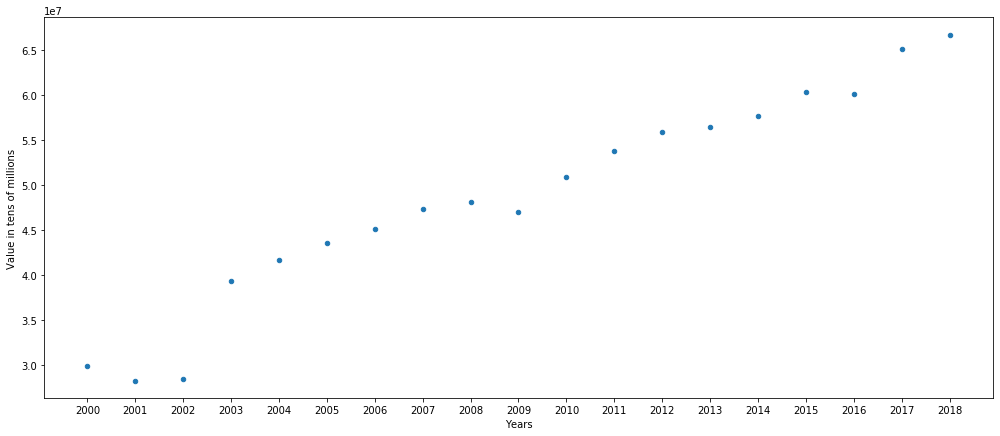

```python
plot = best1countries.plot.scatter(x='TIME_FLOWS',y='Value', figsize=(17,7), xticks=(list(best1countries.TIME_FLOWS)))
plt.ylabel('Value in tens of millions')
plt.xlabel('Years')
```

```
The line that best fit the data has equation equal to: y = 2026679 x - 4022865552

The regression model not only studies the relationship between known values, but it can also predict future values.
Here is the linear prediction for the number of arrivals of the most visited EU country in 2030 : 91292930
```

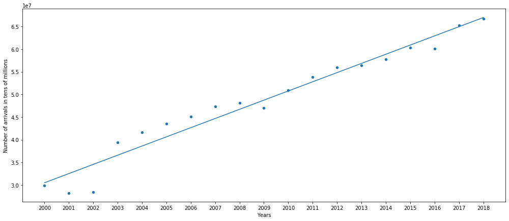

```python
xs1 = best1countries.TIME_FLOWS
ys1 = best1countries.Value
trend1 = np.polyfit(xs1,ys1,deg=1)
best1countries.plot.scatter(x='TIME_FLOWS',y='Value', figsize=(17,7), xticks=(list(best1countries.TIME_FLOWS)))
trendpoly1 = np.poly1d(trend1)
plt.plot(xs1,trendpoly1(xs1))
plt.ylabel('Number of arrivals in tens of millions')
plt.xlabel('Years')

print("The line that best fit the data has equation equal to: y =",int(trend1[0]),"x -",int(abs(trend1[1])))
predict1 = np.poly1d(trend1)
print()
print("The regression model not only studies the relationship between known values, but it can also predict future values.")
to_be_predicted = 2030
print("Here is the linear prediction for the number of arrivals of the most visited EU country in", to_be_predicted,":", int(predict1(to_be_predicted)))
```

## Data analysis

```python
from sklearn.metrics import r2_score
r_squared1 = r2_score(ys1, predict1(xs1))

print("If we want to test the accuracy of our model we can compute the R-squared value.")
print("The closer to 1 the R-squared value, the better the approximation of our model.")
print()
print("Our R-squared value is:", r_squared1, "meaning that we can be about",int(r_squared1*100),"% confident that the prediction is right.")
```

```
If we want to test the accuracy of our model we can compute the R-squared value.
The closer to 1 the R-squared value, the better the approximation of our model.

Our R-squared value is: 0.9545498902171413 meaning that we can be about 95 % confident that the prediction is right.
```

We can now get the ultimate podium and answer the following question: what are the best ranked countries over the years? In other terms, what countries obtained the first position more frequently in the 19 years of our study?

```python
best1countries['GEO_FLOWS'].value_counts()
```

```
Germany (until 1990 former territory of the FRG)    10
Spain                                                6
United Kingdom                                       3
Name: GEO_FLOWS, dtype: int64
```

# QUESTION 2A

**STEP TO ANSWER QUESTION 2 A:**

```
1. Upload dataset "gov_exp.csv"
2. Drop useless rows and columns
3. Sort by 'TIME','GEO' in order to have a compatible dataset to concatenate with the flows dataset (yflows_df)
4. Sort the merged dataset by cultual expenses per year
5. Take the first country for each year
6. Visualize the result graphically and analyze it
```

## Data loading

We now import and read the second Eurostat dataset of our interest. It gives insights about each EU Nation's expenditures on cultural initiatives, education and transport systems.

```python
euexp_df=pd.read_csv('gov_exp.csv')
euexp_df
```

|  | TIME | GEO | SECTOR | COFOG99 | NA_ITEM | UNIT | Value | Flag and Footnotes |
| --- | --- | --- | --- | --- | --- | --- | --- | --- |
| 0 | 2000 | European Union - 27 countries (from 2020) | General government | Transport | Total general government expenditure | Million euro | : | NaN |
| 1 | 2000 | European Union - 27 countries (from 2020) | General government | Transport | Total general government expenditure | Percentage of gross domestic product (GDP) | : | NaN |
| 2 | 2000 | European Union - 27 countries (from 2020) | General government | Cultural services | Total general government expenditure | Million euro | : | NaN |
| 3 | 2000 | European Union - 27 countries (from 2020) | General government | Cultural services | Total general government expenditure | Percentage of gross domestic product (GDP) | : | NaN |
| 4 | 2000 | European Union - 27 countries (from 2020) | General government | Education | Total general government expenditure | Million euro | : | NaN |
| ... | ... | ... | ... | ... | ... | ... | ... | ... |
| 3757 | 2018 | Switzerland | General government | Transport | Total general government expenditure | Percentage of gross domestic product (GDP) | 2.6 | NaN |
| 3758 | 2018 | Switzerland | General government | Cultural services | Total general government expenditure | Million euro | 2,433.4 | NaN |
| 3759 | 2018 | Switzerland | General government | Cultural services | Total general government expenditure | Percentage of gross domestic product (GDP) | 0.4 | NaN |
| 3760 | 2018 | Switzerland | General government | Education | Total general government expenditure | Million euro | 33,255.2 | NaN |
| 3761 | 2018 | Switzerland | General government | Education | Total general government expenditure | Percentage of gross domestic product (GDP) | 5.6 | NaN |

3762 rows × 8 columns

As we did for the first dataset we imported, we need again to ignore aggregate data for all European countries, since we are interested in analyzing and comparing all countries taken separately. Thus, we drop aggregate information.

## Data cleaning

```python
index_to_drop = euexp_df.loc[(euexp_df['GEO']=='European Union - 27 countries (from 2020)') |
                                    (euexp_df['GEO']=='European Union - 28 countries (2013-2020)') |
                                    (euexp_df['UNIT']=='Percentage of gross domestic product (GDP)') |
                                    (euexp_df['COFOG99']=='Transport')]

countriesexp_df = euexp_df.drop(euexp_df.index[index_to_drop.index])
countriesexp_df
```

|  | TIME | GEO | SECTOR | COFOG99 | NA_ITEM | UNIT | Value | Flag and Footnotes |
| --- | --- | --- | --- | --- | --- | --- | --- | --- |
| 14 | 2000 | Belgium | General government | Cultural services | Total general government expenditure | Million euro | : | NaN |
| 16 | 2000 | Belgium | General government | Education | Total general government expenditure | Million euro | 14,184.6 | NaN |
| 20 | 2000 | Bulgaria | General government | Cultural services | Total general government expenditure | Million euro | 51.7 | NaN |
| 22 | 2000 | Bulgaria | General government | Education | Total general government expenditure | Million euro | 597.3 | NaN |
| 26 | 2000 | Czechia | General government | Cultural services | Total general government expenditure | Million euro | 370.4 | NaN |
| ... | ... | ... | ... | ... | ... | ... | ... | ... |
| 3748 | 2018 | Iceland | General government | Education | Total general government expenditure | Million euro | 1,606.1 | NaN |
| 3752 | 2018 | Norway | General government | Cultural services | Total general government expenditure | Million euro | 2,355.8 | NaN |
| 3754 | 2018 | Norway | General government | Education | Total general government expenditure | Million euro | 19,981.9 | NaN |
| 3758 | 2018 | Switzerland | General government | Cultural services | Total general government expenditure | Million euro | 2,433.4 | NaN |
| 3760 | 2018 | Switzerland | General government | Education | Total general government expenditure | Million euro | 33,255.2 | NaN |

1178 rows × 8 columns

Before going on with the data cleaning, we have to check if we have the same countries in both the datasets that we are going to deal with.

We observe that the number of rows of the two dataframes is different. Thus, the two must be differing in some countries (i.e. one dataset includes countries that the other does not include).

To find out what are the differing countries, we extrapolate only the 'GEO' column from both the datasets, we merge them and then we drop the duplicates.

```python
countriesexp_sampledf = countriesexp_df[(countriesexp_df.COFOG99=='Education') & (countriesexp_df.TIME==2018)].GEO
flows_sampledf = flows_df[(flows_df.TIME==2018)].GEO
df_diff = pd.concat([countriesexp_sampledf , flows_sampledf]).drop_duplicates(keep=False)

df_diff
```

```
3748        Iceland
3754         Norway
3760    Switzerland
Name: GEO, dtype: object
```

We got the differing countries and we can now remove them to make the two dataframes compatible.

```python
countries_to_drop = countriesexp_df.loc[(euexp_df['GEO']=='Iceland') |
                                 (euexp_df['GEO']=='Switzerland') |
                                 (euexp_df['GEO']=='Norway')]

compatible_df = countriesexp_df.drop(euexp_df.index[countries_to_drop.index])
compatible_df

# compatible is the former goverexp2
```

|  | TIME | GEO | SECTOR | COFOG99 | NA_ITEM | UNIT | Value | Flag and Footnotes |
| --- | --- | --- | --- | --- | --- | --- | --- | --- |
| 14 | 2000 | Belgium | General government | Cultural services | Total general government expenditure | Million euro | : | NaN |
| 16 | 2000 | Belgium | General government | Education | Total general government expenditure | Million euro | 14,184.6 | NaN |
| 20 | 2000 | Bulgaria | General government | Cultural services | Total general government expenditure | Million euro | 51.7 | NaN |
| 22 | 2000 | Bulgaria | General government | Education | Total general government expenditure | Million euro | 597.3 | NaN |
| 26 | 2000 | Czechia | General government | Cultural services | Total general government expenditure | Million euro | 370.4 | NaN |
| ... | ... | ... | ... | ... | ... | ... | ... | ... |
| 3730 | 2018 | Finland | General government | Education | Total general government expenditure | Million euro | 12,878.0 | NaN |
| 3734 | 2018 | Sweden | General government | Cultural services | Total general government expenditure | Million euro | 2,378.5 | NaN |
| 3736 | 2018 | Sweden | General government | Education | Total general government expenditure | Million euro | 32,449.0 | NaN |
| 3740 | 2018 | United Kingdom | General government | Cultural services | Total general government expenditure | Million euro | 5,605.2 | NaN |
| 3742 | 2018 | United Kingdom | General government | Education | Total general government expenditure | Million euro | 117,315.3 | NaN |

1064 rows × 8 columns

We remove the useless columns.

```python
selectedcols_df = compatible_df[['TIME','GEO','COFOG99','UNIT','Value']]
selectedcols_df

# selectedcols is the former goverexp3
```

|  | TIME | GEO | COFOG99 | UNIT | Value |
| --- | --- | --- | --- | --- | --- |
| 14 | 2000 | Belgium | Cultural services | Million euro | : |
| 16 | 2000 | Belgium | Education | Million euro | 14,184.6 |
| 20 | 2000 | Bulgaria | Cultural services | Million euro | 51.7 |
| 22 | 2000 | Bulgaria | Education | Million euro | 597.3 |
| 26 | 2000 | Czechia | Cultural services | Million euro | 370.4 |
| ... | ... | ... | ... | ... | ... |
| 3730 | 2018 | Finland | Education | Million euro | 12,878.0 |
| 3734 | 2018 | Sweden | Cultural services | Million euro | 2,378.5 |
| 3736 | 2018 | Sweden | Education | Million euro | 32,449.0 |
| 3740 | 2018 | United Kingdom | Cultural services | Million euro | 5,605.2 |
| 3742 | 2018 | United Kingdom | Education | Million euro | 117,315.3 |

1064 rows × 5 columns

We fix issues related to the column 'Value'.

Before the conversion Python sees elements inside the 'Value' column as: <class 'str'>

```python
#If you run this cell after "run all" it will give an error: "Can only use .str accessor with string values!" since
#the program recognize values inside the columns as floats from the previous conversion.

selectedcols_df.Value = selectedcols_df.Value.str.replace(',', '')
selectedcols_df = selectedcols_df.replace(to_replace=":",value="0")
selectedcols_df['Value'] = pd.to_numeric(selectedcols_df['Value'])
```

In order to work with them we want them as floats. After conversion: <class 'numpy.float64'>

We order our current data.

## Data reshaping

```python
ordered_df = selectedcols_df.sort_values(by=['TIME','GEO','COFOG99'], ascending=True, inplace=False)
ordered_df

# ordered is the former goverexp4
```

|  | TIME | GEO | COFOG99 | UNIT | Value |
| --- | --- | --- | --- | --- | --- |
| 128 | 2000 | Austria | Cultural services | Million euro | 1144.7 |
| 130 | 2000 | Austria | Education | Million euro | 11115.8 |
| 14 | 2000 | Belgium | Cultural services | Million euro | 0.0 |
| 16 | 2000 | Belgium | Education | Million euro | 14184.6 |
| 20 | 2000 | Bulgaria | Cultural services | Million euro | 51.7 |
| ... | ... | ... | ... | ... | ... |
| 3628 | 2018 | Spain | Education | Million euro | 48095.0 |
| 3734 | 2018 | Sweden | Cultural services | Million euro | 2378.5 |
| 3736 | 2018 | Sweden | Education | Million euro | 32449.0 |
| 3740 | 2018 | United Kingdom | Cultural services | Million euro | 5605.2 |
| 3742 | 2018 | United Kingdom | Education | Million euro | 117315.3 |

1064 rows × 5 columns

We aggregate governmental investments in Cultural Services and Education. Also, we modify label names.

```python
govinv_df = ordered_df.groupby(by=['TIME','GEO'], as_index=False).sum()
govinv_df['COFOG99'] = 'Cultural Investments'
govinv_df['UNIT'] = 'Million euro'
govinv_df

# govinv is the former goverexp5
```

|  | TIME | GEO | Value | COFOG99 | UNIT |
| --- | --- | --- | --- | --- | --- |
| 0 | 2000 | Austria | 12260.5 | Cultural Investments | Million euro |
| 1 | 2000 | Belgium | 14184.6 | Cultural Investments | Million euro |
| 2 | 2000 | Bulgaria | 649.0 | Cultural Investments | Million euro |
| 3 | 2000 | Croatia | 0.0 | Cultural Investments | Million euro |
| 4 | 2000 | Cyprus | 577.7 | Cultural Investments | Million euro |
| ... | ... | ... | ... | ... | ... |
| 527 | 2018 | Slovakia | 4079.5 | Cultural Investments | Million euro |
| 528 | 2018 | Slovenia | 2771.7 | Cultural Investments | Million euro |
| 529 | 2018 | Spain | 53361.0 | Cultural Investments | Million euro |
| 530 | 2018 | Sweden | 34827.5 | Cultural Investments | Million euro |
| 531 | 2018 | United Kingdom | 122920.5 | Cultural Investments | Million euro |

532 rows × 5 columns

## Data combining

We concatenate data concerning countries' in-flows ('yflows_df') with 'govinv_df'.

```python
merging_df = pd.concat([govinv_df,yflows_df], axis=1)
merging_df

# merging is the former goverexp6
```

|  | TIME | GEO | Value | COFOG99 | UNIT | ARR_RANKING | ARRIVALS |
| --- | --- | --- | --- | --- | --- | --- | --- |
| 0 | 2000 | Austria | 12260.5 | Cultural Investments | Million euro | 4 | 3438464 |
| 1 | 2000 | Belgium | 14184.6 | Cultural Investments | Million euro | 8 | 0 |
| 2 | 2000 | Bulgaria | 649.0 | Cultural Investments | Million euro | 9 | 0 |
| 3 | 2000 | Croatia | 0.0 | Cultural Investments | Million euro | 10 | 0 |
| 4 | 2000 | Cyprus | 577.7 | Cultural Investments | Million euro | 11 | 0 |
| ... | ... | ... | ... | ... | ... | ... | ... |
| 527 | 2018 | Slovakia | 4079.5 | Cultural Investments | Million euro | 25 | 1198661 |
| 528 | 2018 | Slovenia | 2771.7 | Cultural Investments | Million euro | 26 | 890968 |
| 529 | 2018 | Spain | 53361.0 | Cultural Investments | Million euro | 2 | 65092414 |
| 530 | 2018 | Sweden | 34827.5 | Cultural Investments | Million euro | 13 | 8831298 |
| 531 | 2018 | United Kingdom | 122920.5 | Cultural Investments | Million euro | 3 | 49369295 |

532 rows × 7 columns

And we tidy up.

```python
expflows_df = merging_df.sort_values(by=['TIME','Value'], ascending=False, inplace=False)

test = np.arange(1,29)
result = np.repeat(test[np.newaxis,...], 19, axis=0)
result = result.tolist()
flattened = [val for sublist in result for val in sublist]
flattened

expflows_df = expflows_df.rename(columns={'COFOG99':'TYPE OF INVESTMENT'})
expflows_df['CUL_RANKING'] = flattened

expflows_df = expflows_df.reindex(columns=['TIME','GEO','TYPE OF INVESTMENT','UNIT','Value','CUL_RANKING','ARRIVALS','ARR_RANKING'])

expflows_df
# expflows is the former goverexp7
```

|  | TIME | GEO | TYPE OF INVESTMENT | UNIT | Value | CUL_RANKING | ARRIVALS | ARR_RANKING |
| --- | --- | --- | --- | --- | --- | --- | --- | --- |
| 514 | 2018 | Germany (until 1990 former territory of the FRG) | Cultural Investments | Million euro | 152864.0 | 1 | 66754812 | 1 |
| 513 | 2018 | France | Cultural Investments | Million euro | 135381.0 | 2 | 45887748 | 4 |
| 531 | 2018 | United Kingdom | Cultural Investments | Million euro | 122920.5 | 3 | 49369295 | 3 |
| 518 | 2018 | Italy | Cultural Investments | Million euro | 74900.9 | 4 | 34955833 | 5 |
| 529 | 2018 | Spain | Cultural Investments | Million euro | 53361.0 | 5 | 65092414 | 2 |
| ... | ... | ... | ... | ... | ... | ... | ... | ... |
| 4 | 2000 | Cyprus | Cultural Investments | Million euro | 577.7 | 24 | 0 | 11 |
| 7 | 2000 | Estonia | Cultural Investments | Million euro | 468.2 | 25 | 0 | 14 |
| 15 | 2000 | Latvia | Cultural Investments | Million euro | 467.3 | 26 | 0 | 19 |
| 18 | 2000 | Malta | Cultural Investments | Million euro | 225.9 | 27 | 0 | 21 |
| 3 | 2000 | Croatia | Cultural Investments | Million euro | 0.0 | 28 | 0 | 10 |

532 rows × 8 columns

For each year, we extrapolate the countries that invested the most in culture. Thus, we read the position they reached in the most-visited-country ranking.

```python
culturalfirst_df = expflows_df[::28]
culturalfirst_df
```

|  | TIME | GEO | TYPE OF INVESTMENT | UNIT | Value | CUL_RANKING | ARRIVALS | ARR_RANKING |
| --- | --- | --- | --- | --- | --- | --- | --- | --- |
| 514 | 2018 | Germany (until 1990 former territory of the FRG) | Cultural Investments | Million euro | 152864.0 | 1 | 66754812 | 1 |
| 486 | 2017 | Germany (until 1990 former territory of the FRG) | Cultural Investments | Million euro | 145782.0 | 1 | 62382409 | 2 |
| 458 | 2016 | Germany (until 1990 former territory of the FRG) | Cultural Investments | Million euro | 141847.0 | 1 | 59199685 | 2 |
| 447 | 2015 | United Kingdom | Cultural Investments | Million euro | 145448.0 | 1 | 43720027 | 3 |
| 402 | 2014 | Germany (until 1990 former territory of the FRG) | Cultural Investments | Million euro | 137690.0 | 1 | 57702895 | 1 |
| 374 | 2013 | Germany (until 1990 former territory of the FRG) | Cultural Investments | Million euro | 133344.0 | 1 | 56440458 | 1 |
| 345 | 2012 | France | Cultural Investments | Million euro | 130708.0 | 1 | 36508002 | 4 |
| 317 | 2011 | France | Cultural Investments | Million euro | 128282.0 | 1 | 35647257 | 4 |
| 289 | 2010 | France | Cultural Investments | Million euro | 127819.0 | 1 | 34455693 | 4 |
| 261 | 2009 | France | Cultural Investments | Million euro | 124388.0 | 1 | 34291174 | 4 |
| 251 | 2008 | United Kingdom | Cultural Investments | Million euro | 122676.7 | 1 | 38853023 | 3 |
| 223 | 2007 | United Kingdom | Cultural Investments | Million euro | 135917.8 | 1 | 38528286 | 3 |
| 195 | 2006 | United Kingdom | Cultural Investments | Million euro | 129482.4 | 1 | 36709655 | 3 |
| 167 | 2005 | United Kingdom | Cultural Investments | Million euro | 120725.3 | 1 | 35101624 | 3 |
| 139 | 2004 | United Kingdom | Cultural Investments | Million euro | 115652.9 | 1 | 32428102 | 3 |
| 111 | 2003 | United Kingdom | Cultural Investments | Million euro | 109396.1 | 1 | 28871661 | 3 |
| 83 | 2002 | United Kingdom | Cultural Investments | Million euro | 111887.2 | 1 | 28466591 | 1 |
| 38 | 2001 | Germany (until 1990 former territory of the FRG) | Cultural Investments | Million euro | 98934.0 | 1 | 26037572 | 2 |
| 10 | 2000 | Germany (until 1990 former territory of the FRG) | Cultural Investments | Million euro | 94628.0 | 1 | 25488520 | 2 |

## Data visualization

We plot a graph to figure out whether or not a relation between in-flows and cultural investments exists.

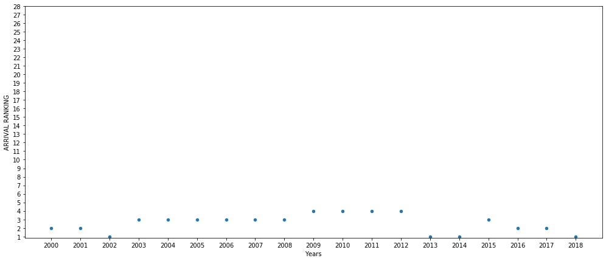

```python
plot = culturalfirst_df.plot.scatter(x='TIME',y='ARR_RANKING', figsize=(17,7), xticks=(list(culturalfirst_df.TIME)), yticks=(list(culturalfirst_df.ARR_RANKING)))
plt.ylabel('ARRIVAL RANKING')
plt.xlabel('Years')
plot.set_yticks([1,2,3,4,5,6,7,8,9,10,11,12,13,14,15,16,17,18,19,20,21,22,23,24,25,26,27,28])
```

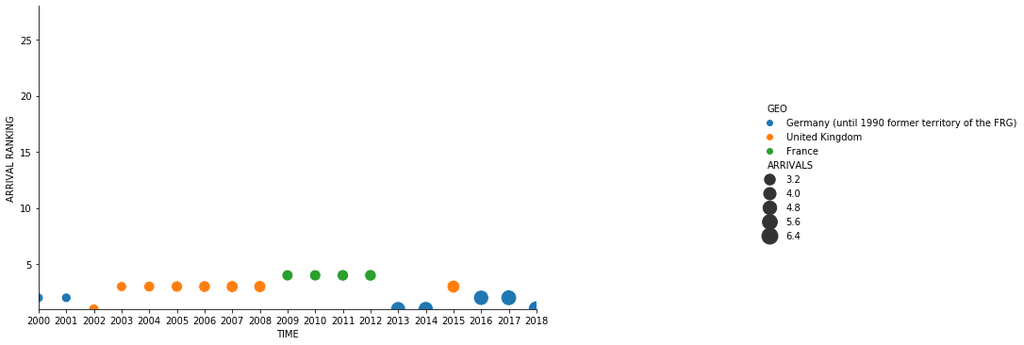

```python
g = sns.relplot(x='TIME', y='ARR_RANKING', size='ARRIVALS', data=culturalfirst_df,
                hue=('GEO'), sizes=(100,300))
g = (g.set_axis_labels("TIME","ARRIVAL RANKING").
     set(xlim=(2000,2018),ylim=(1,28), xticks= culturalfirst_df.TIME.values))

g.fig.set_figwidth(3)
g.fig.set_figheight(2)
plt.gcf().set_size_inches(16,5)
```

## Data analysis

```
The line that best fit the cultural expenses has equation equal to: y = 2594 x - 5086631

The line that best fit the arrivals has equation equal to: y = 2047968 x - 4073443368

Here is the linear prediction for the cultural expenses of the first country and its relative number
of arrivals in 2030:

Prediction of cultural expenses  : 181203 expressed in Mln of €
Prediction of number of arrivals : 83932996
```

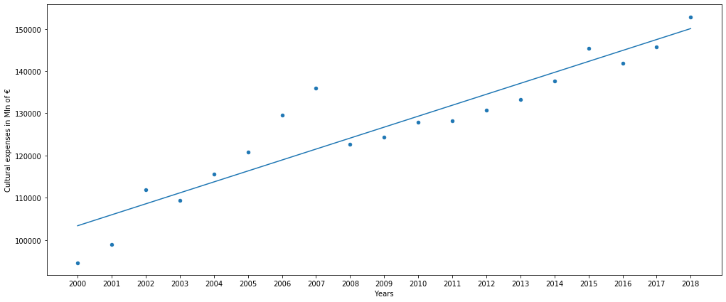

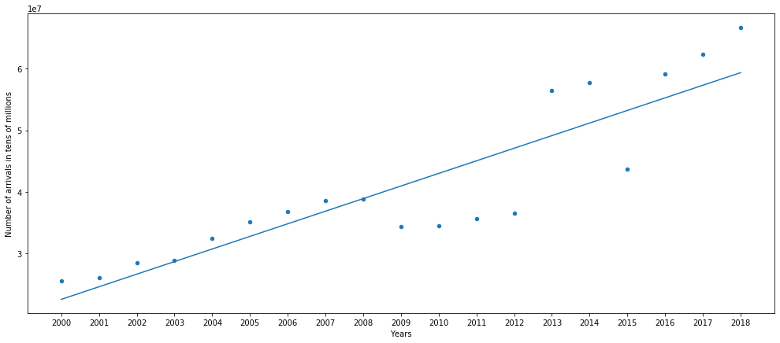

```python
from matplotlib.axes._axes import _log as matplotlib_axes_logger
matplotlib_axes_logger.setLevel('ERROR')

exp_xs2a = culturalfirst_df.TIME
exp_ys2a = culturalfirst_df.Value
exp_trend2a = np.polyfit(exp_xs2a,exp_ys2a,deg=1)
culturalfirst_df.plot.scatter(x='TIME',y='Value', figsize=(17,7), xticks=(list(culturalfirst_df.TIME)))
exp_trendpoly2a = np.poly1d(exp_trend2a)
plt.plot(exp_xs2a,exp_trendpoly2a(exp_xs2a))
plt.ylabel('Cultural expenses in Mln of €')
plt.xlabel('Years')

exp_predict2a = np.poly1d(exp_trend2a)
to_be_predicted = 2030

matplotlib_axes_logger.setLevel('ERROR')
arr_xs2a = culturalfirst_df.TIME
arr_ys2a = culturalfirst_df.ARRIVALS
arr_trend2a = np.polyfit(arr_xs2a,arr_ys2a,deg=1)
culturalfirst_df.plot.scatter(x='TIME',y='ARRIVALS', figsize=(17,7), xticks=(list(culturalfirst_df.TIME)))
arr_trendpoly2a = np.poly1d(arr_trend2a)
plt.plot(arr_xs2a,arr_trendpoly2a(arr_xs2a))
plt.ylabel('Number of arrivals in tens of millions')
plt.xlabel('Years')
print("The line that best fit the cultural expenses has equation equal to: y =",int(exp_trend2a[0]),"x -",int(abs(exp_trend2a[1])))
print()
print("The line that best fit the arrivals has equation equal to: y =",int(arr_trend2a[0]),"x -",int(abs(arr_trend2a[1])))
arr_predict2a = np.poly1d(arr_trend2a)
print()
print("Here is the linear prediction for the cultural expenses of the first country and its relative number")
print("of arrivals in 2030:")
print()
print("Prediction of cultural expenses  :",  int(exp_predict2a(to_be_predicted)), "expressed in Mln of €")
print("Prediction of number of arrivals :", int(arr_predict2a(to_be_predicted)))
```

```python
from sklearn.metrics import r2_score

exp_r_squared2a = r2_score(exp_ys2a, exp_predict2a(exp_xs2a))
print("Let's test the accuracy of our model with the R-squared value.")
print()
print("The R-squared value of the cultural expenses prediction is:", exp_r_squared2a )
print("meaning that we can be about",int(exp_r_squared2a*100),"% confident that the prediction is right.")
print()
arr_r_squared2a = r2_score(arr_ys2a, arr_predict2a(arr_xs2a))
print("The R-squared value of the arrivals prediction is:", arr_r_squared2a )
print("meaning that we can be about",int(arr_r_squared2a*100),"% confident that the prediction is right.")
```

```
Let's test the accuracy of our model with the R-squared value.

The R-squared value of the cultural expenses prediction is: 0.8714221365594255
meaning that we can be about 87 % confident that the prediction is right.

The R-squared value of the arrivals prediction is: 0.7918367225398001
meaning that we can be about 79 % confident that the prediction is right.
```

## QUESTION 2B

**STEP TO ANSWER QUESTION 2 B:**

```
1. Upload dataset "flows.csv"
2. Perform cleaning (take departures) and reordering.
3. Upload dataset "population.csv"
4. Drop useless rows and take only the Value column ordered (needed to get percentage of country departures)
5. Upload dataset "gov_exp.csv"
6. Clean rows and columns and sort by 'TIME', 'GEO'. Concat the previous dataset.
7. Perform operation on the final dataset and then sort by cultural expenses and take the first of each year.
8. Visualize the result and read it through an analysis
```

## Data loading

First of all we upload the file "flows.csv". This time we are interested in examining departures from EU countries. Also, we are going to re-use the same dataset as before ('gov-exp.csv') in order to get each EU Nation's expenditures on cultural initiatives.

```python
eumobility_df = pd.read_csv('flows.csv')
eumobility_df

# eumobility is the former original_flows_df
```

|  | TIME | GEO | UNIT | TRA_MEAS | PARTNER | Value | Flag and Footnotes |
| --- | --- | --- | --- | --- | --- | --- | --- |
| 0 | 2000 | European Union - 27 countries (from 2020) | Passenger | Passengers on board | Extra-EU | : | NaN |
| 1 | 2000 | European Union - 27 countries (from 2020) | Passenger | Passengers on board | Other european countries (aggregate changing a... | : | NaN |
| 2 | 2000 | European Union - 27 countries (from 2020) | Passenger | Passengers on board (arrivals) | Extra-EU | : | NaN |
| 3 | 2000 | European Union - 27 countries (from 2020) | Passenger | Passengers on board (arrivals) | Other european countries (aggregate changing a... | : | NaN |
| 4 | 2000 | European Union - 27 countries (from 2020) | Passenger | Passengers on board (departures) | Extra-EU | : | NaN |
| ... | ... | ... | ... | ... | ... | ... | ... |
| 3415 | 2018 | United Kingdom | Passenger | Passengers on board | Other european countries (aggregate changing a... | 16,905,534 | NaN |
| 3416 | 2018 | United Kingdom | Passenger | Passengers on board (arrivals) | Extra-EU | 40,896,187 | NaN |
| 3417 | 2018 | United Kingdom | Passenger | Passengers on board (arrivals) | Other european countries (aggregate changing a... | 8,473,108 | NaN |
| 3418 | 2018 | United Kingdom | Passenger | Passengers on board (departures) | Extra-EU | 40,250,218 | NaN |
| 3419 | 2018 | United Kingdom | Passenger | Passengers on board (departures) | Other european countries (aggregate changing a... | 8,432,426 | NaN |

3420 rows × 7 columns

## Data cleaning

Now we remove the useless rows and columns. In particular, we want to extrapolate only the departures from the column "TRA_MEAS".

```python
index_to_drop = eumobility_df.loc[(eumobility_df['GEO']=='European Union - 27 countries (from 2020)') |
                                    (eumobility_df['GEO']=='European Union - 28 countries (2013-2020)') |
                                    (eumobility_df['TRA_MEAS']=='Passengers on board') |
                                    (eumobility_df['TRA_MEAS']=='Passengers on board (arrivals)')]

nationalflows_df = eumobility_df.drop(eumobility_df.index[index_to_drop.index])
nationalflows_df = nationalflows_df [['TIME','GEO','TRA_MEAS','PARTNER','Value']]

nationalflows_df

# nationalflows is the former partial
```

|  | TIME | GEO | TRA_MEAS | PARTNER | Value |
| --- | --- | --- | --- | --- | --- |
| 16 | 2000 | Belgium | Passengers on board (departures) | Extra-EU | : |
| 17 | 2000 | Belgium | Passengers on board (departures) | Other european countries (aggregate changing a... | : |
| 22 | 2000 | Bulgaria | Passengers on board (departures) | Extra-EU | : |
| 23 | 2000 | Bulgaria | Passengers on board (departures) | Other european countries (aggregate changing a... | : |
| 28 | 2000 | Czechia | Passengers on board (departures) | Extra-EU | : |
| ... | ... | ... | ... | ... | ... |
| 3407 | 2018 | Finland | Passengers on board (departures) | Other european countries (aggregate changing a... | 1,478,222 |
| 3412 | 2018 | Sweden | Passengers on board (departures) | Extra-EU | 5,224,473 |
| 3413 | 2018 | Sweden | Passengers on board (departures) | Other european countries (aggregate changing a... | 3,617,345 |
| 3418 | 2018 | United Kingdom | Passengers on board (departures) | Extra-EU | 40,250,218 |
| 3419 | 2018 | United Kingdom | Passengers on board (departures) | Other european countries (aggregate changing a... | 8,432,426 |

1064 rows × 5 columns

We perform some cleaning in the column "Value"

```python
nationalflows_df.Value = nationalflows_df.Value.str.replace(',', '')

# Also, we need to replace ":" with 0 since the former is not recognized by the program

nationalflows_df = nationalflows_df.replace(to_replace=":",value="0")

# Now we want to convert the cleaned strings into integers, and we can do this with 2 methods:
# first method is: "to-numeric"
# second method is: "astype(int)"

nationalflows_df['Value'] = pd.to_numeric(nationalflows_df['Value'])
nationalflows_df
```

|  | TIME | GEO | TRA_MEAS | PARTNER | Value |
| --- | --- | --- | --- | --- | --- |
| 16 | 2000 | Belgium | Passengers on board (departures) | Extra-EU | 0 |
| 17 | 2000 | Belgium | Passengers on board (departures) | Other european countries (aggregate changing a... | 0 |
| 22 | 2000 | Bulgaria | Passengers on board (departures) | Extra-EU | 0 |
| 23 | 2000 | Bulgaria | Passengers on board (departures) | Other european countries (aggregate changing a... | 0 |
| 28 | 2000 | Czechia | Passengers on board (departures) | Extra-EU | 0 |
| ... | ... | ... | ... | ... | ... |
| 3407 | 2018 | Finland | Passengers on board (departures) | Other european countries (aggregate changing a... | 1478222 |
| 3412 | 2018 | Sweden | Passengers on board (departures) | Extra-EU | 5224473 |
| 3413 | 2018 | Sweden | Passengers on board (departures) | Other european countries (aggregate changing a... | 3617345 |
| 3418 | 2018 | United Kingdom | Passengers on board (departures) | Extra-EU | 40250218 |
| 3419 | 2018 | United Kingdom | Passengers on board (departures) | Other european countries (aggregate changing a... | 8432426 |

1064 rows × 5 columns

## Data reshaping

```python
groupedflows_df = nationalflows_df.groupby(by=['TIME','GEO','TRA_MEAS'], as_index=False).sum()
groupedflows_df

# groupedflows is the former partial2
```

|  | TIME | GEO | TRA_MEAS | Value |
| --- | --- | --- | --- | --- |
| 0 | 2000 | Austria | Passengers on board (departures) | 3404314 |
| 1 | 2000 | Belgium | Passengers on board (departures) | 0 |
| 2 | 2000 | Bulgaria | Passengers on board (departures) | 0 |
| 3 | 2000 | Croatia | Passengers on board (departures) | 0 |
| 4 | 2000 | Cyprus | Passengers on board (departures) | 0 |
| ... | ... | ... | ... | ... |
| 527 | 2018 | Slovakia | Passengers on board (departures) | 1201572 |
| 528 | 2018 | Slovenia | Passengers on board (departures) | 885636 |
| 529 | 2018 | Spain | Passengers on board (departures) | 65030651 |
| 530 | 2018 | Sweden | Passengers on board (departures) | 8841818 |
| 531 | 2018 | United Kingdom | Passengers on board (departures) | 48682644 |

532 rows × 4 columns

We modify label names.

```python
corporateflows_df = groupedflows_df.rename(columns={'TRA_MEAS': 'TYPE OF FLOW'})
corporateflows_df = groupedflows_df.rename(columns={'Value': 'DEPARTURES'})
corporateflows_df['PARTNER'] = 'Worldwide'

corporateflows_df

# corporateflows is the former partial3
```

|  | TIME | GEO | TRA_MEAS | DEPARTURES | PARTNER |
| --- | --- | --- | --- | --- | --- |
| 0 | 2000 | Austria | Passengers on board (departures) | 3404314 | Worldwide |
| 1 | 2000 | Belgium | Passengers on board (departures) | 0 | Worldwide |
| 2 | 2000 | Bulgaria | Passengers on board (departures) | 0 | Worldwide |
| 3 | 2000 | Croatia | Passengers on board (departures) | 0 | Worldwide |
| 4 | 2000 | Cyprus | Passengers on board (departures) | 0 | Worldwide |
| ... | ... | ... | ... | ... | ... |
| 527 | 2018 | Slovakia | Passengers on board (departures) | 1201572 | Worldwide |
| 528 | 2018 | Slovenia | Passengers on board (departures) | 885636 | Worldwide |
| 529 | 2018 | Spain | Passengers on board (departures) | 65030651 | Worldwide |
| 530 | 2018 | Sweden | Passengers on board (departures) | 8841818 | Worldwide |
| 531 | 2018 | United Kingdom | Passengers on board (departures) | 48682644 | Worldwide |

532 rows × 5 columns

We sort our dataset in order to show, for each year, all the countries from the ones observing the highest number of departures to those showing the lowest values.

```python
bestdep_df = corporateflows_df.sort_values(by=['TIME','DEPARTURES'], ascending=False , inplace=False)
bestdep_df

# bestdep is the former partial4
```

|  | TIME | GEO | TRA_MEAS | DEPARTURES | PARTNER |
| --- | --- | --- | --- | --- | --- |
| 514 | 2018 | Germany (until 1990 former territory of the FRG) | Passengers on board (departures) | 66452651 | Worldwide |
| 529 | 2018 | Spain | Passengers on board (departures) | 65030651 | Worldwide |
| 531 | 2018 | United Kingdom | Passengers on board (departures) | 48682644 | Worldwide |
| 513 | 2018 | France | Passengers on board (departures) | 45545342 | Worldwide |
| 518 | 2018 | Italy | Passengers on board (departures) | 35126658 | Worldwide |
| ... | ... | ... | ... | ... | ... |
| 21 | 2000 | Portugal | Passengers on board (departures) | 0 | Worldwide |
| 22 | 2000 | Romania | Passengers on board (departures) | 0 | Worldwide |
| 23 | 2000 | Slovakia | Passengers on board (departures) | 0 | Worldwide |
| 24 | 2000 | Slovenia | Passengers on board (departures) | 0 | Worldwide |
| 25 | 2000 | Spain | Passengers on board (departures) | 0 | Worldwide |

532 rows × 5 columns

We extrapolate the countries ranked in first position for each year. As we did before, we add the column a column labelled as 'ranking', where we can store the index reordered from the first position to the 28th.

```python
test = np.arange(1,29)
result = np.repeat(test[np.newaxis,...], 19, axis=0)
result = result.tolist()
flattened = [val for sublist in result for val in sublist]
flattened
bestdep_df['RANKING'] = flattened

bestdep_df
```

|  | TIME | GEO | TRA_MEAS | DEPARTURES | PARTNER | RANKING |
| --- | --- | --- | --- | --- | --- | --- |
| 514 | 2018 | Germany (until 1990 former territory of the FRG) | Passengers on board (departures) | 66452651 | Worldwide | 1 |
| 529 | 2018 | Spain | Passengers on board (departures) | 65030651 | Worldwide | 2 |
| 531 | 2018 | United Kingdom | Passengers on board (departures) | 48682644 | Worldwide | 3 |
| 513 | 2018 | France | Passengers on board (departures) | 45545342 | Worldwide | 4 |
| 518 | 2018 | Italy | Passengers on board (departures) | 35126658 | Worldwide | 5 |
| ... | ... | ... | ... | ... | ... | ... |
| 21 | 2000 | Portugal | Passengers on board (departures) | 0 | Worldwide | 24 |
| 22 | 2000 | Romania | Passengers on board (departures) | 0 | Worldwide | 25 |
| 23 | 2000 | Slovakia | Passengers on board (departures) | 0 | Worldwide | 26 |
| 24 | 2000 | Slovenia | Passengers on board (departures) | 0 | Worldwide | 27 |
| 25 | 2000 | Spain | Passengers on board (departures) | 0 | Worldwide | 28 |

532 rows × 6 columns

```python
xdepartures_df = corporateflows_df
xdepartures_df['DEP_RANKING'] = bestdep_df['RANKING']
ydepartures_df = xdepartures_df[['DEP_RANKING', 'DEPARTURES']]

xdepartures_df
```

|  | TIME | GEO | TRA_MEAS | DEPARTURES | PARTNER | DEP_RANKING |
| --- | --- | --- | --- | --- | --- | --- |
| 0 | 2000 | Austria | Passengers on board (departures) | 3404314 | Worldwide | 4 |
| 1 | 2000 | Belgium | Passengers on board (departures) | 0 | Worldwide | 8 |
| 2 | 2000 | Bulgaria | Passengers on board (departures) | 0 | Worldwide | 9 |
| 3 | 2000 | Croatia | Passengers on board (departures) | 0 | Worldwide | 10 |
| 4 | 2000 | Cyprus | Passengers on board (departures) | 0 | Worldwide | 11 |
| ... | ... | ... | ... | ... | ... | ... |
| 527 | 2018 | Slovakia | Passengers on board (departures) | 1201572 | Worldwide | 25 |
| 528 | 2018 | Slovenia | Passengers on board (departures) | 885636 | Worldwide | 27 |
| 529 | 2018 | Spain | Passengers on board (departures) | 65030651 | Worldwide | 2 |
| 530 | 2018 | Sweden | Passengers on board (departures) | 8841818 | Worldwide | 13 |
| 531 | 2018 | United Kingdom | Passengers on board (departures) | 48682644 | Worldwide | 3 |

532 rows × 6 columns

## POPULATION

Since we want to combine more datasets we have to make them compatible. For thi purpose, we follow the same steps as before, i.e. data loading, cleaning and reshaping. We will thus be able to concatenate data concerning out-flows with each government expenses on cultural initiatives.

## Data loading

We import 'population.csv'

```python
eupopulation_df=pd.read_csv('population.csv')
eupopulation_df

# eupopulation is the former original_pop
```

|  | TIME | GEO | AGE | SEX | UNIT | Value | Flag and Footnotes |
| --- | --- | --- | --- | --- | --- | --- | --- |
| 0 | 2000 | European Union - 27 countries (from 2020) | Total | Total | Number | 428,473,834 | be |
| 1 | 2000 | European Union - 28 countries (2013-2020) | Total | Total | Number | 487,259,080 | be |
| 2 | 2000 | Belgium | Total | Total | Number | 10,239,085 | NaN |
| 3 | 2000 | Bulgaria | Total | Total | Number | 8,190,876 | NaN |
| 4 | 2000 | Czechia | Total | Total | Number | 10,278,098 | NaN |
| ... | ... | ... | ... | ... | ... | ... | ... |
| 1059 | 2018 | San Marino | Total | Total | Number | 34,453 | NaN |
| 1060 | 2018 | Ukraine | Total | Total | Number | 42,216,766 | NaN |
| 1061 | 2018 | Armenia | Total | Total | Number | 2,972,732 | NaN |
| 1062 | 2018 | Azerbaijan | Total | Total | Number | 9,898,085 | NaN |
| 1063 | 2018 | Georgia | Total | Total | Number | 3,729,633 | NaN |

1064 rows × 7 columns

## Data cleaning

We clean the dataset and we fix some issues.

```python
eupopulation_df.Value = eupopulation_df.Value.str.replace(',', '')

# Also, we need to replace ":" with 0 since the former is not recognized by the program

eupopulation_df = eupopulation_df.replace(to_replace=":",value="0")

# Now we want to convert the cleaned strings into integers, and we can do this with 2 methods:
# first method is: "to-numeric"
# second method is: "astype(int)"

eupopulation_df['Value'] = pd.to_numeric(eupopulation_df['Value'])

eupopulation_df
```

|  | TIME | GEO | AGE | SEX | UNIT | Value | Flag and Footnotes |
| --- | --- | --- | --- | --- | --- | --- | --- |
| 0 | 2000 | European Union - 27 countries (from 2020) | Total | Total | Number | 428473834 | be |
| 1 | 2000 | European Union - 28 countries (2013-2020) | Total | Total | Number | 487259080 | be |
| 2 | 2000 | Belgium | Total | Total | Number | 10239085 | NaN |
| 3 | 2000 | Bulgaria | Total | Total | Number | 8190876 | NaN |
| 4 | 2000 | Czechia | Total | Total | Number | 10278098 | NaN |
| ... | ... | ... | ... | ... | ... | ... | ... |
| 1059 | 2018 | San Marino | Total | Total | Number | 34453 | NaN |
| 1060 | 2018 | Ukraine | Total | Total | Number | 42216766 | NaN |
| 1061 | 2018 | Armenia | Total | Total | Number | 2972732 | NaN |
| 1062 | 2018 | Azerbaijan | Total | Total | Number | 9898085 | NaN |
| 1063 | 2018 | Georgia | Total | Total | Number | 3729633 | NaN |

1064 rows × 7 columns

We notice that this dataset includes some additional countries with respect to the dataset we used before. As a matter of fact, the number of rows of the dataframes is different.

Therefore, we extrapolate only the 'GEO' column from the datasets we want to compare and we use it to drop the duplicates. In doing so, we are able to get the non-compatible entries, which we are then going to remove.

```python
sample_pop_df = eupopulation_df[(eupopulation_df.TIME==2000)].GEO
sample_xdepartures_df = xdepartures_df[(xdepartures_df.TIME==2000)].GEO

df_diff = pd.concat([sample_pop_df , sample_xdepartures_df]).drop_duplicates(keep=False)
df_diff2 = df_diff.to_frame()
df_diff3 = df_diff2.GEO

df_diff3
```

```
0             European Union - 27 countries (from 2020)
1             European Union - 28 countries (2013-2020)
7                          Germany including former GDR
13                                France (metropolitan)
32    European Economic Area (EU28 - 2013-2020 and I...
33    European Economic Area (EU27 - 2007-2013 and I...
34                      European Free Trade Association
35                                              Iceland
36                                        Liechtenstein
37                                               Norway
38                                          Switzerland
39                                           Montenegro
40                                      North Macedonia
41                                              Albania
42                                               Serbia
43                                               Turkey
44                                              Andorra
45                                              Belarus
46                               Bosnia and Herzegovina
47    Kosovo (under United Nations Security Council ...
48                                              Moldova
49                                               Monaco
50                                               Russia
51                                           San Marino
52                                              Ukraine
53                                              Armenia
54                                           Azerbaijan
55                                              Georgia
Name: GEO, dtype: object
```

We can now remove the differing countries to make the two dataframes compatible.

```python
index_to_drop = eupopulation_df.loc[(eupopulation_df['GEO']=='European Union - 27 countries (from 2020)') |
                                    (eupopulation_df['GEO']=='European Union - 28 countries (2013-2020)') |
                                    (eupopulation_df['GEO']=='Germany including former GDR') |
                                    (eupopulation_df['GEO']=='France (metropolitan)') |
                                    (eupopulation_df['GEO']=='European Economic Area (EU28 - 2013-2020 and IS, LI, NO)') |
                                    (eupopulation_df['GEO']=='European Economic Area (EU27 - 2007-2013 and IS, LI, NO)') |
                                    (eupopulation_df['GEO']=='European Free Trade Association') |
                                    (eupopulation_df['GEO']=='Iceland') |
                                    (eupopulation_df['GEO']=='Liechtenstein') |
                                    (eupopulation_df['GEO']=='Norway') |
                                    (eupopulation_df['GEO']=='Switzerland') |
                                    (eupopulation_df['GEO']=='Montenegro') |
                                    (eupopulation_df['GEO']=='North Macedonia') |
                                    (eupopulation_df['GEO']=='Albania') |
                                    (eupopulation_df['GEO']=='Serbia') |
                                    (eupopulation_df['GEO']=='Turkey') |
                                    (eupopulation_df['GEO']=='Andorra') |
                                    (eupopulation_df['GEO']=='Belarus') |
                                    (eupopulation_df['GEO']=='Bosnia and Herzegovina') |
                                    (eupopulation_df['GEO']=='Kosovo (under United Nations Security Council Resolution 1244/99)') |
                                    (eupopulation_df['GEO']=='Moldova') |
                                    (eupopulation_df['GEO']=='Monaco') |
                                    (eupopulation_df['GEO']=='Russia') |
                                    (eupopulation_df['GEO']=='San Marino') |
                                    (eupopulation_df['GEO']=='Ukraine') |
                                    (eupopulation_df['GEO']=='Armenia') |
                                    (eupopulation_df['GEO']=='Azerbaijan') |
                                    (eupopulation_df['GEO']=='Georgia')]

countriespop_df = eupopulation_df.drop(eupopulation_df.index[index_to_drop.index])
countriespop_df

# countriespop = former partial
```

|  | TIME | GEO | AGE | SEX | UNIT | Value | Flag and Footnotes |
| --- | --- | --- | --- | --- | --- | --- | --- |
| 2 | 2000 | Belgium | Total | Total | Number | 10239085 | NaN |
| 3 | 2000 | Bulgaria | Total | Total | Number | 8190876 | NaN |
| 4 | 2000 | Czechia | Total | Total | Number | 10278098 | NaN |
| 5 | 2000 | Denmark | Total | Total | Number | 5330020 | NaN |
| 6 | 2000 | Germany (until 1990 former territory of the FRG) | Total | Total | Number | 82163475 | NaN |
| ... | ... | ... | ... | ... | ... | ... | ... |
| 1035 | 2018 | Slovenia | Total | Total | Number | 2066880 | NaN |
| 1036 | 2018 | Slovakia | Total | Total | Number | 5443120 | NaN |
| 1037 | 2018 | Finland | Total | Total | Number | 5513130 | NaN |
| 1038 | 2018 | Sweden | Total | Total | Number | 10120242 | NaN |
| 1039 | 2018 | United Kingdom | Total | Total | Number | 66273576 | NaN |

532 rows × 7 columns

## Data reshaping

We order our current data and we change a label name.

```python
sortedpop_df = countriespop_df.sort_values(by=['TIME','GEO'], ascending=True, inplace=False)
sortedpop_df = sortedpop_df.reset_index()
sortedpop_df = sortedpop_df.rename(columns={'Value':'POPULATION'})

sortedpop_df

# sortedpop = former partial2
```

|  | index | TIME | GEO | AGE | SEX | UNIT | POPULATION | Flag and Footnotes |
| --- | --- | --- | --- | --- | --- | --- | --- | --- |
| 0 | 23 | 2000 | Austria | Total | Total | Number | 8002186 | NaN |
| 1 | 2 | 2000 | Belgium | Total | Total | Number | 10239085 | NaN |
| 2 | 3 | 2000 | Bulgaria | Total | Total | Number | 8190876 | NaN |
| 3 | 14 | 2000 | Croatia | Total | Total | Number | 4497735 | e |
| 4 | 16 | 2000 | Cyprus | Total | Total | Number | 690497 | NaN |
| ... | ... | ... | ... | ... | ... | ... | ... | ... |
| 527 | 1036 | 2018 | Slovakia | Total | Total | Number | 5443120 | NaN |
| 528 | 1035 | 2018 | Slovenia | Total | Total | Number | 2066880 | NaN |
| 529 | 1019 | 2018 | Spain | Total | Total | Number | 46658447 | NaN |
| 530 | 1038 | 2018 | Sweden | Total | Total | Number | 10120242 | NaN |
| 531 | 1039 | 2018 | United Kingdom | Total | Total | Number | 66273576 | NaN |

532 rows × 8 columns

```python
popvalue_df = sortedpop_df['POPULATION']
popvalue_df

# popvalue = former pop_value
```

```
0       8002186
1      10239085
2       8190876
3       4497735
4        690497
         ...
527     5443120
528     2066880
529    46658447
530    10120242
531    66273576
Name: POPULATION, Length: 532, dtype: int64
```

## GOVERNMENT CULTURAL EXPENSES

## Data combining

We concatenate data concerning countries' out-flows with the corresponding governmental expenditures.

```python
goverexpb_df = pd.concat([govinv_df,ydepartures_df], axis=1)
goverexpb_df
```

|  | TIME | GEO | Value | COFOG99 | UNIT | DEP_RANKING | DEPARTURES |
| --- | --- | --- | --- | --- | --- | --- | --- |
| 0 | 2000 | Austria | 12260.5 | Cultural Investments | Million euro | 4 | 3404314 |
| 1 | 2000 | Belgium | 14184.6 | Cultural Investments | Million euro | 8 | 0 |
| 2 | 2000 | Bulgaria | 649.0 | Cultural Investments | Million euro | 9 | 0 |
| 3 | 2000 | Croatia | 0.0 | Cultural Investments | Million euro | 10 | 0 |
| 4 | 2000 | Cyprus | 577.7 | Cultural Investments | Million euro | 11 | 0 |
| ... | ... | ... | ... | ... | ... | ... | ... |
| 527 | 2018 | Slovakia | 4079.5 | Cultural Investments | Million euro | 25 | 1201572 |
| 528 | 2018 | Slovenia | 2771.7 | Cultural Investments | Million euro | 27 | 885636 |
| 529 | 2018 | Spain | 53361.0 | Cultural Investments | Million euro | 2 | 65030651 |
| 530 | 2018 | Sweden | 34827.5 | Cultural Investments | Million euro | 13 | 8841818 |
| 531 | 2018 | United Kingdom | 122920.5 | Cultural Investments | Million euro | 3 | 48682644 |

532 rows × 7 columns

```python
goverexpb2_df = pd.concat([goverexpb_df,popvalue_df], axis=1)
goverexpb2_df
```

|  | TIME | GEO | Value | COFOG99 | UNIT | DEP_RANKING | DEPARTURES | POPULATION |
| --- | --- | --- | --- | --- | --- | --- | --- | --- |
| 0 | 2000 | Austria | 12260.5 | Cultural Investments | Million euro | 4 | 3404314 | 8002186 |
| 1 | 2000 | Belgium | 14184.6 | Cultural Investments | Million euro | 8 | 0 | 10239085 |
| 2 | 2000 | Bulgaria | 649.0 | Cultural Investments | Million euro | 9 | 0 | 8190876 |
| 3 | 2000 | Croatia | 0.0 | Cultural Investments | Million euro | 10 | 0 | 4497735 |
| 4 | 2000 | Cyprus | 577.7 | Cultural Investments | Million euro | 11 | 0 | 690497 |
| ... | ... | ... | ... | ... | ... | ... | ... | ... |
| 527 | 2018 | Slovakia | 4079.5 | Cultural Investments | Million euro | 25 | 1201572 | 5443120 |
| 528 | 2018 | Slovenia | 2771.7 | Cultural Investments | Million euro | 27 | 885636 | 2066880 |
| 529 | 2018 | Spain | 53361.0 | Cultural Investments | Million euro | 2 | 65030651 | 46658447 |
| 530 | 2018 | Sweden | 34827.5 | Cultural Investments | Million euro | 13 | 8841818 | 10120242 |
| 531 | 2018 | United Kingdom | 122920.5 | Cultural Investments | Million euro | 3 | 48682644 | 66273576 |

532 rows × 8 columns

```python
goverexpb2_df['%DEPARTURES'] = goverexpb2_df['DEPARTURES']/goverexpb2_df['POPULATION']
goverexpb2_df = goverexpb2_df[['TIME','GEO','COFOG99','UNIT','Value','DEP_RANKING','DEPARTURES', '%DEPARTURES']]

goverexpb2_df
```

|  | TIME | GEO | COFOG99 | UNIT | Value | DEP_RANKING | DEPARTURES | %DEPARTURES |
| --- | --- | --- | --- | --- | --- | --- | --- | --- |
| 0 | 2000 | Austria | Cultural Investments | Million euro | 12260.5 | 4 | 3404314 | 0.425423 |
| 1 | 2000 | Belgium | Cultural Investments | Million euro | 14184.6 | 8 | 0 | 0.000000 |
| 2 | 2000 | Bulgaria | Cultural Investments | Million euro | 649.0 | 9 | 0 | 0.000000 |
| 3 | 2000 | Croatia | Cultural Investments | Million euro | 0.0 | 10 | 0 | 0.000000 |
| 4 | 2000 | Cyprus | Cultural Investments | Million euro | 577.7 | 11 | 0 | 0.000000 |
| ... | ... | ... | ... | ... | ... | ... | ... | ... |
| 527 | 2018 | Slovakia | Cultural Investments | Million euro | 4079.5 | 25 | 1201572 | 0.220751 |
| 528 | 2018 | Slovenia | Cultural Investments | Million euro | 2771.7 | 27 | 885636 | 0.428489 |
| 529 | 2018 | Spain | Cultural Investments | Million euro | 53361.0 | 2 | 65030651 | 1.393759 |
| 530 | 2018 | Sweden | Cultural Investments | Million euro | 34827.5 | 13 | 8841818 | 0.873677 |
| 531 | 2018 | United Kingdom | Cultural Investments | Million euro | 122920.5 | 3 | 48682644 | 0.734571 |

532 rows × 8 columns

It is important to underline that each country has a different number of inhabitants. Thus, we expect this aspect to have an impact on the number of departures registered, but we also guess that other factors may affect the result (e.g. very touristic country). We decide to check the percentage of departures for each country, in order to get a more realistic view about the result.

```python
# We rank the % of departures

perdepsorted_df = goverexpb2_df.sort_values(by=['TIME','%DEPARTURES'], ascending=False, inplace=False)
perdepsorted_df
```

|  | TIME | GEO | COFOG99 | UNIT | Value | DEP_RANKING | DEPARTURES | %DEPARTURES |
| --- | --- | --- | --- | --- | --- | --- | --- | --- |
| 508 | 2018 | Cyprus | Cultural Investments | Million euro | 1155.1 | 16 | 5007321 | 5.793928 |
| 522 | 2018 | Malta | Cultural Investments | Million euro | 737.6 | 24 | 2139028 | 4.496581 |
| 517 | 2018 | Ireland | Cultural Investments | Million euro | 11030.4 | 7 | 16782646 | 3.474386 |
| 510 | 2018 | Denmark | Cultural Investments | Million euro | 21124.1 | 11 | 10934485 | 1.891390 |
| 523 | 2018 | Netherlands | Cultural Investments | Million euro | 42688.0 | 6 | 29552997 | 1.720089 |
| ... | ... | ... | ... | ... | ... | ... | ... | ... |
| 21 | 2000 | Portugal | Cultural Investments | Million euro | 8619.8 | 24 | 0 | 0.000000 |
| 22 | 2000 | Romania | Cultural Investments | Million euro | 1270.3 | 25 | 0 | 0.000000 |
| 23 | 2000 | Slovakia | Cultural Investments | Million euro | 839.0 | 26 | 0 | 0.000000 |
| 24 | 2000 | Slovenia | Cultural Investments | Million euro | 1516.1 | 27 | 0 | 0.000000 |
| 25 | 2000 | Spain | Cultural Investments | Million euro | 29708.0 | 28 | 0 | 0.000000 |

532 rows × 8 columns

Now we have the number of departures, the percentage departures, the departures ranking and also the percentage departures ranking.

```python
test = np.arange(1,29)
result = np.repeat(test[np.newaxis,...], 19, axis=0)
result = result.tolist()
flattened = [val for sublist in result for val in sublist]
flattened

perdepsorted_df['%RANKING'] = flattened
perdepsorted_df

#CYPRUS AND MALTA
```

|  | TIME | GEO | COFOG99 | UNIT | Value | DEP_RANKING | DEPARTURES | %DEPARTURES | %RANKING |
| --- | --- | --- | --- | --- | --- | --- | --- | --- | --- |
| 508 | 2018 | Cyprus | Cultural Investments | Million euro | 1155.1 | 16 | 5007321 | 5.793928 | 1 |
| 522 | 2018 | Malta | Cultural Investments | Million euro | 737.6 | 24 | 2139028 | 4.496581 | 2 |
| 517 | 2018 | Ireland | Cultural Investments | Million euro | 11030.4 | 7 | 16782646 | 3.474386 | 3 |
| 510 | 2018 | Denmark | Cultural Investments | Million euro | 21124.1 | 11 | 10934485 | 1.891390 | 4 |
| 523 | 2018 | Netherlands | Cultural Investments | Million euro | 42688.0 | 6 | 29552997 | 1.720089 | 5 |
| ... | ... | ... | ... | ... | ... | ... | ... | ... | ... |
| 21 | 2000 | Portugal | Cultural Investments | Million euro | 8619.8 | 24 | 0 | 0.000000 | 24 |
| 22 | 2000 | Romania | Cultural Investments | Million euro | 1270.3 | 25 | 0 | 0.000000 | 25 |
| 23 | 2000 | Slovakia | Cultural Investments | Million euro | 839.0 | 26 | 0 | 0.000000 | 26 |
| 24 | 2000 | Slovenia | Cultural Investments | Million euro | 1516.1 | 27 | 0 | 0.000000 | 27 |
| 25 | 2000 | Spain | Cultural Investments | Million euro | 29708.0 | 28 | 0 | 0.000000 | 28 |

532 rows × 9 columns

We notice that Cyprus and Malta are the first two countries with more departures. Of course, we know that they represent two particularly touristic destinations. For sure, we can guess that part of the departures from Cypro and Malta have to be considered as the back-home-trips of some tourists and not the 'real' departure of inhabitants.

```python
goverexpb3_df = perdepsorted_df.sort_values(by=['TIME','Value'], ascending=False, inplace=False)

test = np.arange(1,29)
result = np.repeat(test[np.newaxis,...], 19, axis=0)
result = result.tolist()
flattened = [val for sublist in result for val in sublist]

goverexpb3_df = goverexpb3_df.rename(columns={'COFOG99':'TYPE OF INVESTMENT'})
goverexpb3_df['CUL_RANKING'] = flattened
goverexpb3_df = goverexpb3_df.rename(columns={'RANKING':'DEP_RANKING'})
goverexpb3_df = goverexpb3_df.reindex(columns=['TIME','GEO','TYPE OF INVESTMENT','UNIT','Value','CUL_RANKING','DEPARTURES','DEP_RANKING','%DEPARTURES','%RANKING'])

goverexpb3_df
```

|  | TIME | GEO | TYPE OF INVESTMENT | UNIT | Value | CUL_RANKING | DEPARTURES | DEP_RANKING | %DEPARTURES | %RANKING |
| --- | --- | --- | --- | --- | --- | --- | --- | --- | --- | --- |
| 514 | 2018 | Germany (until 1990 former territory of the FRG) | Cultural Investments | Million euro | 152864.0 | 1 | 66452651 | 1 | 0.802642 | 15 |
| 513 | 2018 | France | Cultural Investments | Million euro | 135381.0 | 2 | 45545342 | 4 | 0.680605 | 19 |
| 531 | 2018 | United Kingdom | Cultural Investments | Million euro | 122920.5 | 3 | 48682644 | 3 | 0.734571 | 17 |
| 518 | 2018 | Italy | Cultural Investments | Million euro | 74900.9 | 4 | 35126658 | 5 | 0.580760 | 20 |
| 529 | 2018 | Spain | Cultural Investments | Million euro | 53361.0 | 5 | 65030651 | 2 | 1.393759 | 8 |
| ... | ... | ... | ... | ... | ... | ... | ... | ... | ... | ... |
| 4 | 2000 | Cyprus | Cultural Investments | Million euro | 577.7 | 24 | 0 | 11 | 0.000000 | 11 |
| 7 | 2000 | Estonia | Cultural Investments | Million euro | 468.2 | 25 | 0 | 14 | 0.000000 | 14 |
| 15 | 2000 | Latvia | Cultural Investments | Million euro | 467.3 | 26 | 0 | 19 | 0.000000 | 19 |
| 18 | 2000 | Malta | Cultural Investments | Million euro | 225.9 | 27 | 0 | 21 | 0.000000 | 21 |
| 3 | 2000 | Croatia | Cultural Investments | Million euro | 0.0 | 28 | 0 | 10 | 0.000000 | 10 |

532 rows × 10 columns

For each year, we extrapolate the countries that invested the most in culture. Thus, we read the position they reached in the countries with more departures.

Now we take per each year the first country with the highest value for cultural investments.

```python
culturalfirstb_df = goverexpb3_df[::28]

culturalfirstb_df
```

|  | TIME | GEO | TYPE OF INVESTMENT | UNIT | Value | CUL_RANKING | DEPARTURES | DEP_RANKING | %DEPARTURES | %RANKING |
| --- | --- | --- | --- | --- | --- | --- | --- | --- | --- | --- |
| 514 | 2018 | Germany (until 1990 former territory of the FRG) | Cultural Investments | Million euro | 152864.0 | 1 | 66452651 | 1 | 0.802642 | 15 |
| 486 | 2017 | Germany (until 1990 former territory of the FRG) | Cultural Investments | Million euro | 145782.0 | 1 | 62028643 | 2 | 0.751665 | 14 |
| 458 | 2016 | Germany (until 1990 former territory of the FRG) | Cultural Investments | Million euro | 141847.0 | 1 | 59005712 | 2 | 0.718043 | 13 |
| 447 | 2015 | United Kingdom | Cultural Investments | Million euro | 145448.0 | 1 | 43250971 | 3 | 0.666904 | 16 |
| 402 | 2014 | Germany (until 1990 former territory of the FRG) | Cultural Investments | Million euro | 137690.0 | 1 | 57634471 | 1 | 0.713585 | 13 |
| 374 | 2013 | Germany (until 1990 former territory of the FRG) | Cultural Investments | Million euro | 133344.0 | 1 | 56412856 | 1 | 0.700574 | 13 |
| 345 | 2012 | France | Cultural Investments | Million euro | 130708.0 | 1 | 36534234 | 4 | 0.559680 | 17 |
| 317 | 2011 | France | Cultural Investments | Million euro | 128282.0 | 1 | 35530349 | 4 | 0.546800 | 17 |
| 289 | 2010 | France | Cultural Investments | Million euro | 127819.0 | 1 | 34286503 | 4 | 0.530268 | 17 |
| 261 | 2009 | France | Cultural Investments | Million euro | 124388.0 | 1 | 34274032 | 4 | 0.532617 | 15 |
| 251 | 2008 | United Kingdom | Cultural Investments | Million euro | 122676.7 | 1 | 38768097 | 3 | 0.629642 | 12 |
| 223 | 2007 | United Kingdom | Cultural Investments | Million euro | 135917.8 | 1 | 38438538 | 3 | 0.629384 | 11 |
| 195 | 2006 | United Kingdom | Cultural Investments | Million euro | 129482.4 | 1 | 36656014 | 3 | 0.604682 | 11 |
| 167 | 2005 | United Kingdom | Cultural Investments | Million euro | 120725.3 | 1 | 35034612 | 3 | 0.582144 | 11 |
| 139 | 2004 | United Kingdom | Cultural Investments | Million euro | 115652.9 | 1 | 32362265 | 3 | 0.541231 | 11 |
| 111 | 2003 | United Kingdom | Cultural Investments | Million euro | 109396.1 | 1 | 28789411 | 3 | 0.483844 | 11 |
| 83 | 2002 | United Kingdom | Cultural Investments | Million euro | 111887.2 | 1 | 28327078 | 1 | 0.478178 | 4 |
| 38 | 2001 | Germany (until 1990 former territory of the FRG) | Cultural Investments | Million euro | 98934.0 | 1 | 25661251 | 2 | 0.311955 | 9 |
| 10 | 2000 | Germany (until 1990 former territory of the FRG) | Cultural Investments | Million euro | 94628.0 | 1 | 25266164 | 2 | 0.307511 | 4 |

And this is the podium for the 19 years of our study:

```python
culturalfirstb0_df = goverexpb3_df[::28]
culturalfirstb1_df = goverexpb3_df[1::28]
culturalfirstb2_df = goverexpb3_df[2::28]
culturalfirstb3_df = culturalfirstb0_df.append(culturalfirstb1_df).append(culturalfirstb2_df)
culturalfirstb3_df = culturalfirstb3_df.sort_index()
culturalfirstb3_df = culturalfirstb3_df.sort_values(by=['TIME','Value'], ascending=False)

culturalfirstb3_df
```

|  | TIME | GEO | TYPE OF INVESTMENT | UNIT | Value | CUL_RANKING | DEPARTURES | DEP_RANKING | %DEPARTURES | %RANKING |
| --- | --- | --- | --- | --- | --- | --- | --- | --- | --- | --- |
| 514 | 2018 | Germany (until 1990 former territory of the FRG) | Cultural Investments | Million euro | 152864.0 | 1 | 66452651 | 1 | 0.802642 | 15 |
| 513 | 2018 | France | Cultural Investments | Million euro | 135381.0 | 2 | 45545342 | 4 | 0.680605 | 19 |
| 531 | 2018 | United Kingdom | Cultural Investments | Million euro | 122920.5 | 3 | 48682644 | 3 | 0.734571 | 17 |
| 486 | 2017 | Germany (until 1990 former territory of the FRG) | Cultural Investments | Million euro | 145782.0 | 1 | 62028643 | 2 | 0.751665 | 14 |
| 485 | 2017 | France | Cultural Investments | Million euro | 139747.0 | 2 | 43482445 | 4 | 0.650839 | 18 |
| 503 | 2017 | United Kingdom | Cultural Investments | Million euro | 122908.3 | 3 | 45538457 | 3 | 0.691610 | 16 |
| 458 | 2016 | Germany (until 1990 former territory of the FRG) | Cultural Investments | Million euro | 141847.0 | 1 | 59005712 | 2 | 0.718043 | 13 |
| 457 | 2016 | France | Cultural Investments | Million euro | 136220.0 | 2 | 40611436 | 4 | 0.609430 | 17 |
| 475 | 2016 | United Kingdom | Cultural Investments | Million euro | 130471.8 | 3 | 43342998 | 3 | 0.662949 | 15 |
| 447 | 2015 | United Kingdom | Cultural Investments | Million euro | 145448.0 | 1 | 43250971 | 3 | 0.666904 | 16 |
| 430 | 2015 | Germany (until 1990 former territory of the FRG) | Cultural Investments | Million euro | 138446.0 | 2 | 60240610 | 1 | 0.741902 | 13 |
| 429 | 2015 | France | Cultural Investments | Million euro | 135315.0 | 3 | 39951576 | 4 | 0.601154 | 17 |
| 402 | 2014 | Germany (until 1990 former territory of the FRG) | Cultural Investments | Million euro | 137690.0 | 1 | 57634471 | 1 | 0.713585 | 13 |
| 401 | 2014 | France | Cultural Investments | Million euro | 134633.0 | 2 | 39114221 | 4 | 0.591153 | 17 |
| 419 | 2014 | United Kingdom | Cultural Investments | Million euro | 130636.9 | 3 | 42455494 | 3 | 0.659747 | 15 |
| 374 | 2013 | Germany (until 1990 former territory of the FRG) | Cultural Investments | Million euro | 133344.0 | 1 | 56412856 | 1 | 0.700574 | 13 |
| 373 | 2013 | France | Cultural Investments | Million euro | 132984.0 | 2 | 37709740 | 4 | 0.574841 | 17 |
| 391 | 2013 | United Kingdom | Cultural Investments | Million euro | 117880.3 | 3 | 41267370 | 3 | 0.645758 | 15 |
| 345 | 2012 | France | Cultural Investments | Million euro | 130708.0 | 1 | 36534234 | 4 | 0.559680 | 17 |
| 346 | 2012 | Germany (until 1990 former territory of the FRG) | Cultural Investments | Million euro | 127596.0 | 2 | 55932655 | 1 | 0.696304 | 13 |
| 363 | 2012 | United Kingdom | Cultural Investments | Million euro | 124865.8 | 3 | 39803204 | 3 | 0.626871 | 14 |
| 317 | 2011 | France | Cultural Investments | Million euro | 128282.0 | 1 | 35530349 | 4 | 0.546800 | 17 |
| 318 | 2011 | Germany (until 1990 former territory of the FRG) | Cultural Investments | Million euro | 126148.0 | 2 | 53735623 | 1 | 0.669836 | 13 |
| 335 | 2011 | United Kingdom | Cultural Investments | Million euro | 117643.0 | 3 | 39432187 | 3 | 0.625684 | 14 |
| 289 | 2010 | France | Cultural Investments | Million euro | 127819.0 | 1 | 34286503 | 4 | 0.530268 | 17 |
| 307 | 2010 | United Kingdom | Cultural Investments | Million euro | 123893.7 | 2 | 38641581 | 3 | 0.618164 | 14 |
| 290 | 2010 | Germany (until 1990 former territory of the FRG) | Cultural Investments | Million euro | 122123.0 | 3 | 50897872 | 1 | 0.622206 | 13 |
| 261 | 2009 | France | Cultural Investments | Million euro | 124388.0 | 1 | 34274032 | 4 | 0.532617 | 15 |
| 262 | 2009 | Germany (until 1990 former territory of the FRG) | Cultural Investments | Million euro | 115816.0 | 2 | 46969843 | 1 | 0.572787 | 13 |
| 279 | 2009 | United Kingdom | Cultural Investments | Million euro | 114245.6 | 3 | 37962074 | 3 | 0.611874 | 11 |
| 251 | 2008 | United Kingdom | Cultural Investments | Million euro | 122676.7 | 1 | 38768097 | 3 | 0.629642 | 12 |
| 233 | 2008 | France | Cultural Investments | Million euro | 121449.0 | 2 | 35640263 | 4 | 0.556817 | 15 |
| 234 | 2008 | Germany (until 1990 former territory of the FRG) | Cultural Investments | Million euro | 109625.0 | 3 | 47976954 | 2 | 0.583535 | 13 |
| 223 | 2007 | United Kingdom | Cultural Investments | Million euro | 135917.8 | 1 | 38438538 | 3 | 0.629384 | 11 |
| 205 | 2007 | France | Cultural Investments | Million euro | 116590.0 | 2 | 34777965 | 4 | 0.546436 | 14 |
| 206 | 2007 | Germany (until 1990 former territory of the FRG) | Cultural Investments | Million euro | 107054.0 | 3 | 47256346 | 2 | 0.574092 | 13 |
| 195 | 2006 | United Kingdom | Cultural Investments | Million euro | 129482.4 | 1 | 36656014 | 3 | 0.604682 | 11 |
| 177 | 2006 | France | Cultural Investments | Million euro | 114314.0 | 2 | 33188212 | 4 | 0.524884 | 14 |
| 178 | 2006 | Germany (until 1990 former territory of the FRG) | Cultural Investments | Million euro | 104571.0 | 3 | 44333049 | 2 | 0.537774 | 13 |
| 167 | 2005 | United Kingdom | Cultural Investments | Million euro | 120725.3 | 1 | 35034612 | 3 | 0.582144 | 11 |
| 149 | 2005 | France | Cultural Investments | Million euro | 109412.0 | 2 | 31860043 | 4 | 0.507545 | 13 |
| 150 | 2005 | Germany (until 1990 former territory of the FRG) | Cultural Investments | Million euro | 102536.0 | 3 | 43235517 | 2 | 0.524061 | 12 |
| 139 | 2004 | United Kingdom | Cultural Investments | Million euro | 115652.9 | 1 | 32362265 | 3 | 0.541231 | 11 |
| 121 | 2004 | France | Cultural Investments | Million euro | 105758.0 | 2 | 30170309 | 4 | 0.484335 | 13 |
| 122 | 2004 | Germany (until 1990 former territory of the FRG) | Cultural Investments | Million euro | 101424.0 | 3 | 40360845 | 2 | 0.489035 | 12 |
| 111 | 2003 | United Kingdom | Cultural Investments | Million euro | 109396.1 | 1 | 28789411 | 3 | 0.483844 | 11 |
| 93 | 2003 | France | Cultural Investments | Million euro | 104815.0 | 2 | 27548217 | 4 | 0.445302 | 12 |
| 94 | 2003 | Germany (until 1990 former territory of the FRG) | Cultural Investments | Million euro | 101097.0 | 3 | 34796113 | 2 | 0.421584 | 13 |
| 83 | 2002 | United Kingdom | Cultural Investments | Million euro | 111887.2 | 1 | 28327078 | 1 | 0.478178 | 4 |
| 65 | 2002 | France | Cultural Investments | Million euro | 101863.0 | 2 | 17557092 | 3 | 0.285834 | 8 |
| 66 | 2002 | Germany (until 1990 former territory of the FRG) | Cultural Investments | Million euro | 100288.0 | 3 | 25689222 | 2 | 0.311610 | 6 |
| 38 | 2001 | Germany (until 1990 former territory of the FRG) | Cultural Investments | Million euro | 98934.0 | 1 | 25661251 | 2 | 0.311955 | 9 |
| 55 | 2001 | United Kingdom | Cultural Investments | Million euro | 97534.9 | 2 | 28019844 | 1 | 0.474914 | 5 |
| 37 | 2001 | France | Cultural Investments | Million euro | 95418.0 | 3 | 0 | 22 | 0.000000 | 22 |
| 10 | 2000 | Germany (until 1990 former territory of the FRG) | Cultural Investments | Million euro | 94628.0 | 1 | 25266164 | 2 | 0.307511 | 4 |
| 27 | 2000 | United Kingdom | Cultural Investments | Million euro | 92060.5 | 2 | 29844781 | 1 | 0.507692 | 1 |
| 9 | 2000 | France | Cultural Investments | Million euro | 90475.0 | 3 | 0 | 15 | 0.000000 | 15 |

## Data visualization

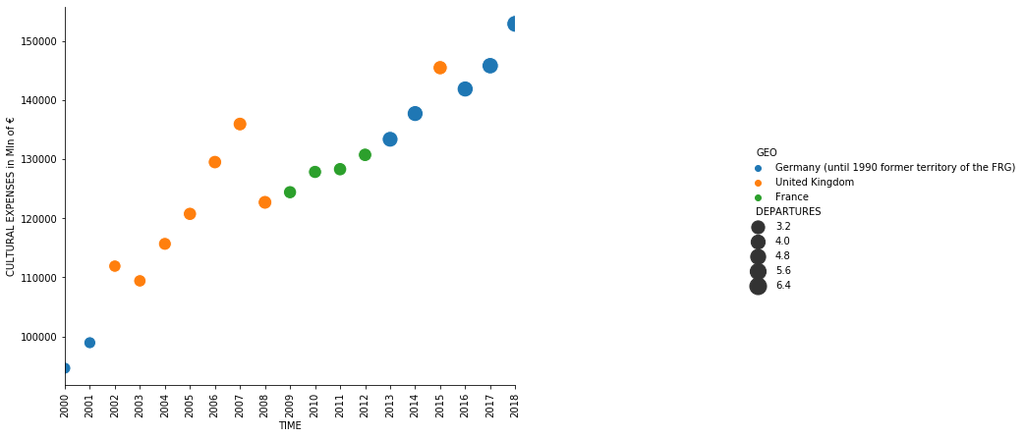

```python
#sns.set(style="ticks")
g = sns.relplot(x='TIME', y='Value', size='DEPARTURES', data=culturalfirstb_df, sizes=(150,300), hue='GEO')
g = (g.set_axis_labels("TIME","CULTURAL EXPENSES in Mln of €").set
     (xlim=(2000,2018), xticks = culturalfirstb_df.TIME.values))
plt.xticks(rotation=90)
g.fig.set_figwidth(3)
g.fig.set_figheight(2)
plt.gcf().set_size_inches(16,6)
```

## Data analysis

```
The line that best fit the cultural expenses has equation equal to: y = 2594 x - 5086631

The line that best fit the relative countries departures has equation equal to: y = 2042715 x - 4063041646

Here is the linear prediction for the cultural expenses of the first country and its relative number
of departures in 2030 :

Prediction of cultural expenses    : 181203 expressed in Mln of €
Prediction of number of departures : 83671445
```

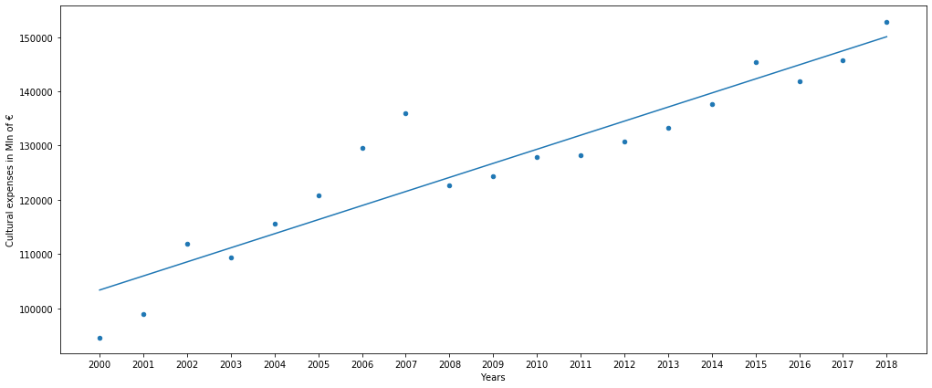

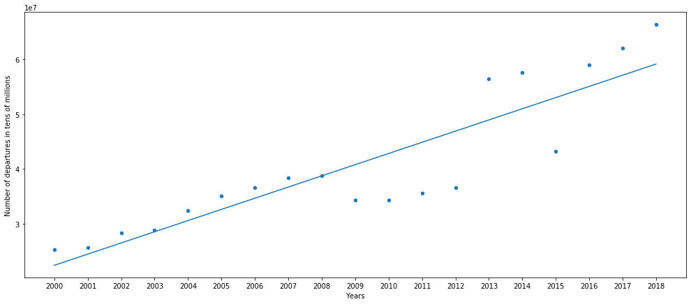

```python
from matplotlib.axes._axes import _log as matplotlib_axes_logger
matplotlib_axes_logger.setLevel('ERROR')

#sns.set_style("white")
exp_xs2b = culturalfirstb_df.TIME
exp_ys2b = culturalfirstb_df.Value
exp_trend2b = np.polyfit(exp_xs2b,exp_ys2b,deg=1)
culturalfirstb_df.plot.scatter(x='TIME',y='Value', figsize=(17,7), xticks=(list(culturalfirstb_df.TIME)))
exp_trendpoly2b = np.poly1d(exp_trend2b)
plt.plot(exp_xs2b,exp_trendpoly2b(exp_xs2b))
plt.ylabel('Cultural expenses in Mln of €')
plt.xlabel('Years')

exp_predict2b = np.poly1d(exp_trend2b)
to_be_predicted = 2030

matplotlib_axes_logger.setLevel('ERROR')
#sns.set_style("white")
dep_xs2b = culturalfirstb_df.TIME
dep_ys2b = culturalfirstb_df.DEPARTURES
dep_trend2b = np.polyfit(dep_xs2b,dep_ys2b,deg=1)
culturalfirstb_df.plot.scatter(x='TIME',y='DEPARTURES', figsize=(17,7), xticks=(list(culturalfirstb_df.TIME)))
dep_trendpoly2b = np.poly1d(dep_trend2b)
plt.plot(dep_xs2b,dep_trendpoly2b(dep_xs2b))
plt.ylabel('Number of departures in tens of millions')
plt.xlabel('Years')
print("The line that best fit the cultural expenses has equation equal to: y =",int(exp_trend2b[0]),"x -",int(abs(exp_trend2b[1])))
print()
print("The line that best fit the relative countries departures has equation equal to: y =",int(dep_trend2b[0]),"x -",int(abs(dep_trend2b[1])))
dep_predict2b = np.poly1d(dep_trend2b)
print()
print("Here is the linear prediction for the cultural expenses of the first country and its relative number")
print("of departures in",to_be_predicted,":")
print()
print("Prediction of cultural expenses    :",  int(exp_predict2b(to_be_predicted)), "expressed in Mln of €")
print("Prediction of number of departures :", int(dep_predict2b(to_be_predicted)))
```

```python
from sklearn.metrics import r2_score

exp_r_squared2b = r2_score(exp_ys2b, exp_predict2b(exp_xs2b))
print("Let's test the accuracy of our model with the R-squared value.")
print()
print("The R-squared value of the cultural expenses prediction is:", exp_r_squared2b )
print("meaning that we can be about",int(exp_r_squared2b*100),"% confident that the prediction is right. (It's the same of the previous check)")
print()
dep_r_squared2b = r2_score(dep_ys2b, dep_predict2b(dep_xs2b))
print("The R-squared value of the departures prediction is:", dep_r_squared2b )
print("meaning that we can be about",int(dep_r_squared2b*100),"% confident that the prediction is right.")
```

```
Let's test the accuracy of our model with the R-squared value.

The R-squared value of the cultural expenses prediction is: 0.8714221365594255
meaning that we can be about 87 % confident that the prediction is right. (It's the same of the previous check)

The R-squared value of the departures prediction is: 0.79124936033248
meaning that we can be about 79 % confident that the prediction is right.
```

# QUESTION 3

**STEP TO ANSWER QUESTION 3:**

```
1. Upload dataset "flows.csv"
2. Manipulate dataset (we need the total flow) and make it ready to be concatenated
3. Upload dataset "gov_exp.csv"
4. Clean it, sort it by 'TIME','GEO' and concatenate it with the previous dataset.
5. Sort the final dataset by time and transport expenses
6. Plot a graph and perform analysis
```

#### PREPARING DATASET TO CONCAT

## Data loading

We import the file 'flows.csv'

```python
original_flows_df=pd.read_csv('flows.csv')

original_flows_df
```

|  | TIME | GEO | UNIT | TRA_MEAS | PARTNER | Value | Flag and Footnotes |
| --- | --- | --- | --- | --- | --- | --- | --- |
| 0 | 2000 | European Union - 27 countries (from 2020) | Passenger | Passengers on board | Extra-EU | : | NaN |
| 1 | 2000 | European Union - 27 countries (from 2020) | Passenger | Passengers on board | Other european countries (aggregate changing a... | : | NaN |
| 2 | 2000 | European Union - 27 countries (from 2020) | Passenger | Passengers on board (arrivals) | Extra-EU | : | NaN |
| 3 | 2000 | European Union - 27 countries (from 2020) | Passenger | Passengers on board (arrivals) | Other european countries (aggregate changing a... | : | NaN |
| 4 | 2000 | European Union - 27 countries (from 2020) | Passenger | Passengers on board (departures) | Extra-EU | : | NaN |
| ... | ... | ... | ... | ... | ... | ... | ... |
| 3415 | 2018 | United Kingdom | Passenger | Passengers on board | Other european countries (aggregate changing a... | 16,905,534 | NaN |
| 3416 | 2018 | United Kingdom | Passenger | Passengers on board (arrivals) | Extra-EU | 40,896,187 | NaN |
| 3417 | 2018 | United Kingdom | Passenger | Passengers on board (arrivals) | Other european countries (aggregate changing a... | 8,473,108 | NaN |
| 3418 | 2018 | United Kingdom | Passenger | Passengers on board (departures) | Extra-EU | 40,250,218 | NaN |
| 3419 | 2018 | United Kingdom | Passenger | Passengers on board (departures) | Other european countries (aggregate changing a... | 8,432,426 | NaN |

3420 rows × 7 columns

## Data cleaning

We fix some issues concerning the entries of 'value' column and we remove the useless columns.

```python
index_to_drop = original_flows_df.loc[(original_flows_df['GEO']=='European Union - 27 countries (from 2020)') |
                                      (original_flows_df['GEO']=='European Union - 28 countries (2013-2020)') |
                                      (original_flows_df['TRA_MEAS']=='Passengers on board (departures)') |
                                      (original_flows_df['TRA_MEAS']=='Passengers on board (arrivals)')]

onboard_df = original_flows_df.drop(original_flows_df.index[index_to_drop.index])

onboard_df
```

|  | TIME | GEO | UNIT | TRA_MEAS | PARTNER | Value | Flag and Footnotes |
| --- | --- | --- | --- | --- | --- | --- | --- |
| 12 | 2000 | Belgium | Passenger | Passengers on board | Extra-EU | : | NaN |
| 13 | 2000 | Belgium | Passenger | Passengers on board | Other european countries (aggregate changing a... | : | NaN |
| 18 | 2000 | Bulgaria | Passenger | Passengers on board | Extra-EU | : | NaN |
| 19 | 2000 | Bulgaria | Passenger | Passengers on board | Other european countries (aggregate changing a... | : | NaN |
| 24 | 2000 | Czechia | Passenger | Passengers on board | Extra-EU | : | NaN |
| ... | ... | ... | ... | ... | ... | ... | ... |
| 3403 | 2018 | Finland | Passenger | Passengers on board | Other european countries (aggregate changing a... | 2,964,797 | NaN |
| 3408 | 2018 | Sweden | Passenger | Passengers on board | Extra-EU | 10,443,565 | NaN |
| 3409 | 2018 | Sweden | Passenger | Passengers on board | Other european countries (aggregate changing a... | 7,229,551 | NaN |
| 3414 | 2018 | United Kingdom | Passenger | Passengers on board | Extra-EU | 81,146,405 | NaN |
| 3415 | 2018 | United Kingdom | Passenger | Passengers on board | Other european countries (aggregate changing a... | 16,905,534 | NaN |

1064 rows × 7 columns

```python
onboard_df = onboard_df.replace(to_replace=":",value="0")

onboard_df.Value = onboard_df.Value.str.replace(',', '')

onboard_df['Value'] = pd.to_numeric(onboard_df['Value'])

onboard_df = onboard_df.rename(columns={'TRA_MEAS':'TYPE OF FLOW'})

onboard_df = onboard_df[['TIME','GEO','TYPE OF FLOW','PARTNER','Value']]

onboard_df
```

|  | TIME | GEO | TYPE OF FLOW | PARTNER | Value |
| --- | --- | --- | --- | --- | --- |
| 12 | 2000 | Belgium | Passengers on board | Extra-EU | 0 |
| 13 | 2000 | Belgium | Passengers on board | Other european countries (aggregate changing a... | 0 |
| 18 | 2000 | Bulgaria | Passengers on board | Extra-EU | 0 |
| 19 | 2000 | Bulgaria | Passengers on board | Other european countries (aggregate changing a... | 0 |
| 24 | 2000 | Czechia | Passengers on board | Extra-EU | 0 |
| ... | ... | ... | ... | ... | ... |
| 3403 | 2018 | Finland | Passengers on board | Other european countries (aggregate changing a... | 2964797 |
| 3408 | 2018 | Sweden | Passengers on board | Extra-EU | 10443565 |
| 3409 | 2018 | Sweden | Passengers on board | Other european countries (aggregate changing a... | 7229551 |
| 3414 | 2018 | United Kingdom | Passengers on board | Extra-EU | 81146405 |
| 3415 | 2018 | United Kingdom | Passengers on board | Other european countries (aggregate changing a... | 16905534 |

1064 rows × 5 columns

## Data reshaping

We order our dataset and we group it by the columns: "TIME", "GEO" and "TYPE OF FLOW".

```python
onboard1_df = onboard_df.sort_values(by=['TIME','GEO'])

onboard1_df
```

|  | TIME | GEO | TYPE OF FLOW | PARTNER | Value |
| --- | --- | --- | --- | --- | --- |
| 126 | 2000 | Austria | Passengers on board | Extra-EU | 4654149 |
| 127 | 2000 | Austria | Passengers on board | Other european countries (aggregate changing a... | 2188629 |
| 12 | 2000 | Belgium | Passengers on board | Extra-EU | 0 |
| 13 | 2000 | Belgium | Passengers on board | Other european countries (aggregate changing a... | 0 |
| 18 | 2000 | Bulgaria | Passengers on board | Extra-EU | 0 |
| ... | ... | ... | ... | ... | ... |
| 3301 | 2018 | Spain | Passengers on board | Other european countries (aggregate changing a... | 53878160 |
| 3408 | 2018 | Sweden | Passengers on board | Extra-EU | 10443565 |
| 3409 | 2018 | Sweden | Passengers on board | Other european countries (aggregate changing a... | 7229551 |
| 3414 | 2018 | United Kingdom | Passengers on board | Extra-EU | 81146405 |
| 3415 | 2018 | United Kingdom | Passengers on board | Other european countries (aggregate changing a... | 16905534 |

1064 rows × 5 columns

```python
grouped_onboard_df = onboard1_df.groupby(by=['TIME','GEO','TYPE OF FLOW'],as_index=False).sum()

grouped_onboard_df
```

|  | TIME | GEO | TYPE OF FLOW | Value |
| --- | --- | --- | --- | --- |
| 0 | 2000 | Austria | Passengers on board | 6842778 |
| 1 | 2000 | Belgium | Passengers on board | 0 |
| 2 | 2000 | Bulgaria | Passengers on board | 0 |
| 3 | 2000 | Croatia | Passengers on board | 0 |
| 4 | 2000 | Cyprus | Passengers on board | 0 |
| ... | ... | ... | ... | ... |
| 527 | 2018 | Slovakia | Passengers on board | 2400233 |
| 528 | 2018 | Slovenia | Passengers on board | 1776604 |
| 529 | 2018 | Spain | Passengers on board | 130123065 |
| 530 | 2018 | Sweden | Passengers on board | 17673116 |
| 531 | 2018 | United Kingdom | Passengers on board | 98051939 |

532 rows × 4 columns

```python
sorted_onboard_df = grouped_onboard_df.sort_values(by=['TIME','Value'], ascending=False)

sorted_onboard_df['PARTNER']='Worldwide'

sorted_onboard_df
```

|  | TIME | GEO | TYPE OF FLOW | Value | PARTNER |
| --- | --- | --- | --- | --- | --- |
| 514 | 2018 | Germany (until 1990 former territory of the FRG) | Passengers on board | 133207463 | Worldwide |
| 529 | 2018 | Spain | Passengers on board | 130123065 | Worldwide |
| 531 | 2018 | United Kingdom | Passengers on board | 98051939 | Worldwide |
| 513 | 2018 | France | Passengers on board | 91433090 | Worldwide |
| 518 | 2018 | Italy | Passengers on board | 70082491 | Worldwide |
| ... | ... | ... | ... | ... | ... |
| 21 | 2000 | Portugal | Passengers on board | 0 | Worldwide |
| 22 | 2000 | Romania | Passengers on board | 0 | Worldwide |
| 23 | 2000 | Slovakia | Passengers on board | 0 | Worldwide |
| 24 | 2000 | Slovenia | Passengers on board | 0 | Worldwide |
| 25 | 2000 | Spain | Passengers on board | 0 | Worldwide |

532 rows × 5 columns

We rank the countries based on the in/out tourist flows

```python
test = np.arange(1,29)
result = np.repeat(test[np.newaxis,...], 19, axis=0)
result = result.tolist()
flattened = [val for sublist in result for val in sublist]
flattened

sorted_onboard_df['RANKING'] = flattened

sorted_onboard_df
```

|  | TIME | GEO | TYPE OF FLOW | Value | PARTNER | RANKING |
| --- | --- | --- | --- | --- | --- | --- |
| 514 | 2018 | Germany (until 1990 former territory of the FRG) | Passengers on board | 133207463 | Worldwide | 1 |
| 529 | 2018 | Spain | Passengers on board | 130123065 | Worldwide | 2 |
| 531 | 2018 | United Kingdom | Passengers on board | 98051939 | Worldwide | 3 |
| 513 | 2018 | France | Passengers on board | 91433090 | Worldwide | 4 |
| 518 | 2018 | Italy | Passengers on board | 70082491 | Worldwide | 5 |
| ... | ... | ... | ... | ... | ... | ... |
| 21 | 2000 | Portugal | Passengers on board | 0 | Worldwide | 24 |
| 22 | 2000 | Romania | Passengers on board | 0 | Worldwide | 25 |
| 23 | 2000 | Slovakia | Passengers on board | 0 | Worldwide | 26 |
| 24 | 2000 | Slovenia | Passengers on board | 0 | Worldwide | 27 |
| 25 | 2000 | Spain | Passengers on board | 0 | Worldwide | 28 |

532 rows × 6 columns

```python
x_onboard_df = grouped_onboard_df
x_onboard_df['FLOW_RANKING'] = sorted_onboard_df['RANKING']
x_onboard_df['ON_BOARD'] = sorted_onboard_df['Value']

y_onboard_df = x_onboard_df[['FLOW_RANKING','ON_BOARD']]

x_onboard_df
```

|  | TIME | GEO | TYPE OF FLOW | Value | FLOW_RANKING | ON_BOARD |
| --- | --- | --- | --- | --- | --- | --- |
| 0 | 2000 | Austria | Passengers on board | 6842778 | 4 | 6842778 |
| 1 | 2000 | Belgium | Passengers on board | 0 | 8 | 0 |
| 2 | 2000 | Bulgaria | Passengers on board | 0 | 9 | 0 |
| 3 | 2000 | Croatia | Passengers on board | 0 | 10 | 0 |
| 4 | 2000 | Cyprus | Passengers on board | 0 | 11 | 0 |
| ... | ... | ... | ... | ... | ... | ... |
| 527 | 2018 | Slovakia | Passengers on board | 2400233 | 25 | 2400233 |
| 528 | 2018 | Slovenia | Passengers on board | 1776604 | 27 | 1776604 |
| 529 | 2018 | Spain | Passengers on board | 130123065 | 2 | 130123065 |
| 530 | 2018 | Sweden | Passengers on board | 17673116 | 13 | 17673116 |
| 531 | 2018 | United Kingdom | Passengers on board | 98051939 | 3 | 98051939 |

532 rows × 6 columns

```python
first_onboard_df = sorted_onboard_df[::28]

first_onboard_df
```

|  | TIME | GEO | TYPE OF FLOW | Value | PARTNER | RANKING |
| --- | --- | --- | --- | --- | --- | --- |
| 514 | 2018 | Germany (until 1990 former territory of the FRG) | Passengers on board | 133207463 | Worldwide | 1 |
| 501 | 2017 | Spain | Passengers on board | 130429537 | Worldwide | 1 |
| 473 | 2016 | Spain | Passengers on board | 120185088 | Worldwide | 1 |
| 430 | 2015 | Germany (until 1990 former territory of the FRG) | Passengers on board | 120558342 | Worldwide | 1 |
| 402 | 2014 | Germany (until 1990 former territory of the FRG) | Passengers on board | 115337366 | Worldwide | 1 |
| 374 | 2013 | Germany (until 1990 former territory of the FRG) | Passengers on board | 112853314 | Worldwide | 1 |
| 346 | 2012 | Germany (until 1990 former territory of the FRG) | Passengers on board | 111861757 | Worldwide | 1 |
| 318 | 2011 | Germany (until 1990 former territory of the FRG) | Passengers on board | 107562692 | Worldwide | 1 |
| 290 | 2010 | Germany (until 1990 former territory of the FRG) | Passengers on board | 101828424 | Worldwide | 1 |
| 262 | 2009 | Germany (until 1990 former territory of the FRG) | Passengers on board | 93960314 | Worldwide | 1 |
| 249 | 2008 | Spain | Passengers on board | 96086172 | Worldwide | 1 |
| 206 | 2007 | Germany (until 1990 former territory of the FRG) | Passengers on board | 94618136 | Worldwide | 1 |
| 193 | 2006 | Spain | Passengers on board | 89891060 | Worldwide | 1 |
| 165 | 2005 | Spain | Passengers on board | 87414261 | Worldwide | 1 |
| 137 | 2004 | Spain | Passengers on board | 83317392 | Worldwide | 1 |
| 109 | 2003 | Spain | Passengers on board | 78311979 | Worldwide | 1 |
| 83 | 2002 | United Kingdom | Passengers on board | 56793669 | Worldwide | 1 |
| 55 | 2001 | United Kingdom | Passengers on board | 56274672 | Worldwide | 1 |
| 27 | 2000 | United Kingdom | Passengers on board | 59694874 | Worldwide | 1 |

## GOVERNMENT TRANSPORT EXPENSES

## Data loading

In order to answer to the last question we have to combine the previous dataset with the one about the government transport expenses so we upload it and then we clean it.

```python
original_gov_df = pd.read_csv('gov_exp.csv')
original_gov_df
```

|  | TIME | GEO | SECTOR | COFOG99 | NA_ITEM | UNIT | Value | Flag and Footnotes |
| --- | --- | --- | --- | --- | --- | --- | --- | --- |
| 0 | 2000 | European Union - 27 countries (from 2020) | General government | Transport | Total general government expenditure | Million euro | : | NaN |
| 1 | 2000 | European Union - 27 countries (from 2020) | General government | Transport | Total general government expenditure | Percentage of gross domestic product (GDP) | : | NaN |
| 2 | 2000 | European Union - 27 countries (from 2020) | General government | Cultural services | Total general government expenditure | Million euro | : | NaN |
| 3 | 2000 | European Union - 27 countries (from 2020) | General government | Cultural services | Total general government expenditure | Percentage of gross domestic product (GDP) | : | NaN |
| 4 | 2000 | European Union - 27 countries (from 2020) | General government | Education | Total general government expenditure | Million euro | : | NaN |
| ... | ... | ... | ... | ... | ... | ... | ... | ... |
| 3757 | 2018 | Switzerland | General government | Transport | Total general government expenditure | Percentage of gross domestic product (GDP) | 2.6 | NaN |
| 3758 | 2018 | Switzerland | General government | Cultural services | Total general government expenditure | Million euro | 2,433.4 | NaN |
| 3759 | 2018 | Switzerland | General government | Cultural services | Total general government expenditure | Percentage of gross domestic product (GDP) | 0.4 | NaN |
| 3760 | 2018 | Switzerland | General government | Education | Total general government expenditure | Million euro | 33,255.2 | NaN |
| 3761 | 2018 | Switzerland | General government | Education | Total general government expenditure | Percentage of gross domestic product (GDP) | 5.6 | NaN |

3762 rows × 8 columns

## Data cleaning

In order to make this dataframe compatible with the one above, we drop some useless columns and some countries that we don't have in the other dataset.

```python
index_to_drop = original_gov_df.loc[(original_gov_df['GEO']=='European Union - 27 countries (from 2020)') |
                                    (original_gov_df['GEO']=='European Union - 28 countries (2013-2020)') |
                                    (original_gov_df['GEO']=='Iceland') |
                                    (original_gov_df['GEO']=='Switzerland') |
                                    (original_gov_df['GEO']=='Norway') |
                                    (original_gov_df['UNIT']=='Percentage of gross domestic product (GDP)') |
                                    (original_gov_df['COFOG99']=='Education') |
                                    (original_gov_df['COFOG99']=='Cultural services')]

transport_df = original_gov_df.drop(original_gov_df.index[index_to_drop.index])

transport_df
```

|  | TIME | GEO | SECTOR | COFOG99 | NA_ITEM | UNIT | Value | Flag and Footnotes |
| --- | --- | --- | --- | --- | --- | --- | --- | --- |
| 12 | 2000 | Belgium | General government | Transport | Total general government expenditure | Million euro | : | NaN |
| 18 | 2000 | Bulgaria | General government | Transport | Total general government expenditure | Million euro | 301.1 | NaN |
| 24 | 2000 | Czechia | General government | Transport | Total general government expenditure | Million euro | 2,402.5 | NaN |
| 30 | 2000 | Denmark | General government | Transport | Total general government expenditure | Million euro | 2,911.9 | NaN |
| 36 | 2000 | Germany (until 1990 former territory of the FRG) | General government | Transport | Total general government expenditure | Million euro | 38,541.0 | NaN |
| ... | ... | ... | ... | ... | ... | ... | ... | ... |
| 3714 | 2018 | Slovenia | General government | Transport | Total general government expenditure | Million euro | 1,156.2 | NaN |
| 3720 | 2018 | Slovakia | General government | Transport | Total general government expenditure | Million euro | 3,561.4 | p |
| 3726 | 2018 | Finland | General government | Transport | Total general government expenditure | Million euro | 5,305.0 | NaN |
| 3732 | 2018 | Sweden | General government | Transport | Total general government expenditure | Million euro | 12,673.6 | NaN |
| 3738 | 2018 | United Kingdom | General government | Transport | Total general government expenditure | Million euro | 41,838.6 | NaN |

532 rows × 8 columns

```python
transport1_df = transport_df

transport1_df = transport1_df.replace(to_replace=":",value="0")

transport1_df.Value = transport1_df.Value.str.replace(',', '')

# Also, we need to replace ":" with 0 since the former is not recognized by the program

# Now we want to convert the cleaned strings into integers, and we can do this with 2 methods:
# first method is: "to-numeric"
# second method is: "astype(int)"

transport1_df['Value'] = pd.to_numeric(transport1_df['Value'])

transport1_df
```

|  | TIME | GEO | SECTOR | COFOG99 | NA_ITEM | UNIT | Value | Flag and Footnotes |
| --- | --- | --- | --- | --- | --- | --- | --- | --- |
| 12 | 2000 | Belgium | General government | Transport | Total general government expenditure | Million euro | 0.0 | NaN |
| 18 | 2000 | Bulgaria | General government | Transport | Total general government expenditure | Million euro | 301.1 | NaN |
| 24 | 2000 | Czechia | General government | Transport | Total general government expenditure | Million euro | 2402.5 | NaN |
| 30 | 2000 | Denmark | General government | Transport | Total general government expenditure | Million euro | 2911.9 | NaN |
| 36 | 2000 | Germany (until 1990 former territory of the FRG) | General government | Transport | Total general government expenditure | Million euro | 38541.0 | NaN |
| ... | ... | ... | ... | ... | ... | ... | ... | ... |
| 3714 | 2018 | Slovenia | General government | Transport | Total general government expenditure | Million euro | 1156.2 | NaN |
| 3720 | 2018 | Slovakia | General government | Transport | Total general government expenditure | Million euro | 3561.4 | p |
| 3726 | 2018 | Finland | General government | Transport | Total general government expenditure | Million euro | 5305.0 | NaN |
| 3732 | 2018 | Sweden | General government | Transport | Total general government expenditure | Million euro | 12673.6 | NaN |
| 3738 | 2018 | United Kingdom | General government | Transport | Total general government expenditure | Million euro | 41838.6 | NaN |

532 rows × 8 columns

## Data reshaping

We order our dataframe and we change a label name.

```python
transport2_df = transport1_df[['TIME','GEO','COFOG99','UNIT','Value']]
transport2_df = transport2_df.rename(columns={'COFOG99':'TYPE OF INVESTMENT'})
transport2_df = transport2_df.sort_values(by=['TIME','GEO'])
transport2_df = transport2_df.reset_index()
transport2_df
```

|  | index | TIME | GEO | TYPE OF INVESTMENT | UNIT | Value |
| --- | --- | --- | --- | --- | --- | --- |
| 0 | 126 | 2000 | Austria | Transport | Million euro | 4951.2 |
| 1 | 12 | 2000 | Belgium | Transport | Million euro | 0.0 |
| 2 | 18 | 2000 | Bulgaria | Transport | Million euro | 301.1 |
| 3 | 72 | 2000 | Croatia | Transport | Million euro | 0.0 |
| 4 | 84 | 2000 | Cyprus | Transport | Million euro | 111.5 |
| ... | ... | ... | ... | ... | ... | ... |
| 527 | 3720 | 2018 | Slovakia | Transport | Million euro | 3561.4 |
| 528 | 3714 | 2018 | Slovenia | Transport | Million euro | 1156.2 |
| 529 | 3624 | 2018 | Spain | Transport | Million euro | 18653.0 |
| 530 | 3732 | 2018 | Sweden | Transport | Million euro | 12673.6 |
| 531 | 3738 | 2018 | United Kingdom | Transport | Million euro | 41838.6 |

532 rows × 6 columns

## Data combining

Now we are ready to concatenate the two datasets.

```python
transport3_df = pd.concat([transport2_df,y_onboard_df], axis=1)
transport3_df
```

|  | index | TIME | GEO | TYPE OF INVESTMENT | UNIT | Value | FLOW_RANKING | ON_BOARD |
| --- | --- | --- | --- | --- | --- | --- | --- | --- |
| 0 | 126 | 2000 | Austria | Transport | Million euro | 4951.2 | 4 | 6842778 |
| 1 | 12 | 2000 | Belgium | Transport | Million euro | 0.0 | 8 | 0 |
| 2 | 18 | 2000 | Bulgaria | Transport | Million euro | 301.1 | 9 | 0 |
| 3 | 72 | 2000 | Croatia | Transport | Million euro | 0.0 | 10 | 0 |
| 4 | 84 | 2000 | Cyprus | Transport | Million euro | 111.5 | 11 | 0 |
| ... | ... | ... | ... | ... | ... | ... | ... | ... |
| 527 | 3720 | 2018 | Slovakia | Transport | Million euro | 3561.4 | 25 | 2400233 |
| 528 | 3714 | 2018 | Slovenia | Transport | Million euro | 1156.2 | 27 | 1776604 |
| 529 | 3624 | 2018 | Spain | Transport | Million euro | 18653.0 | 2 | 130123065 |
| 530 | 3732 | 2018 | Sweden | Transport | Million euro | 12673.6 | 13 | 17673116 |
| 531 | 3738 | 2018 | United Kingdom | Transport | Million euro | 41838.6 | 3 | 98051939 |

532 rows × 8 columns

```python
transport4_df = transport3_df.sort_values(by=['TIME','Value'], ascending=False)

test = np.arange(1,29)
result = np.repeat(test[np.newaxis,...], 19, axis=0)
result = result.tolist()
flattened = [val for sublist in result for val in sublist]
flattened

transport4_df['RANKING'] = flattened

transport4_df = transport4_df.reindex(columns=['TIME','GEO','TYPE OF INVESTMENT','UNIT','Value','RANKING','ON_BOARD','FLOW_RANKING'])

transport4_df
```

|  | TIME | GEO | TYPE OF INVESTMENT | UNIT | Value | RANKING | ON_BOARD | FLOW_RANKING |
| --- | --- | --- | --- | --- | --- | --- | --- | --- |
| 514 | 2018 | Germany (until 1990 former territory of the FRG) | Transport | Million euro | 54060.0 | 1 | 133207463 | 1 |
| 513 | 2018 | France | Transport | Million euro | 48629.0 | 2 | 91433090 | 4 |
| 531 | 2018 | United Kingdom | Transport | Million euro | 41838.6 | 3 | 98051939 | 3 |
| 518 | 2018 | Italy | Transport | Million euro | 29558.4 | 4 | 70082491 | 5 |
| 529 | 2018 | Spain | Transport | Million euro | 18653.0 | 5 | 130123065 | 2 |
| ... | ... | ... | ... | ... | ... | ... | ... | ... |
| 18 | 2000 | Malta | Transport | Million euro | 0.0 | 24 | 0 | 21 |
| 20 | 2000 | Poland | Transport | Million euro | 0.0 | 25 | 0 | 23 |
| 22 | 2000 | Romania | Transport | Million euro | 0.0 | 26 | 0 | 25 |
| 23 | 2000 | Slovakia | Transport | Million euro | 0.0 | 27 | 0 | 26 |
| 26 | 2000 | Sweden | Transport | Million euro | 0.0 | 28 | 5453494 | 5 |

532 rows × 8 columns

```python
transportfirst_df = transport4_df[::28]
transportfirst_df
```

|  | TIME | GEO | TYPE OF INVESTMENT | UNIT | Value | RANKING | ON_BOARD | FLOW_RANKING |
| --- | --- | --- | --- | --- | --- | --- | --- | --- |
| 514 | 2018 | Germany (until 1990 former territory of the FRG) | Transport | Million euro | 54060.0 | 1 | 133207463 | 1 |
| 486 | 2017 | Germany (until 1990 former territory of the FRG) | Transport | Million euro | 51521.0 | 1 | 124411052 | 2 |
| 458 | 2016 | Germany (until 1990 former territory of the FRG) | Transport | Million euro | 48099.0 | 1 | 118205397 | 2 |
| 447 | 2015 | United Kingdom | Transport | Million euro | 46609.4 | 1 | 86970998 | 3 |
| 402 | 2014 | Germany (until 1990 former territory of the FRG) | Transport | Million euro | 45195.0 | 1 | 115337366 | 1 |
| 374 | 2013 | Germany (until 1990 former territory of the FRG) | Transport | Million euro | 44743.0 | 1 | 112853314 | 1 |
| 346 | 2012 | Germany (until 1990 former territory of the FRG) | Transport | Million euro | 43203.0 | 1 | 111861757 | 1 |
| 318 | 2011 | Germany (until 1990 former territory of the FRG) | Transport | Million euro | 44090.0 | 1 | 107562692 | 1 |
| 290 | 2010 | Germany (until 1990 former territory of the FRG) | Transport | Million euro | 41883.0 | 1 | 101828424 | 1 |
| 262 | 2009 | Germany (until 1990 former territory of the FRG) | Transport | Million euro | 41906.0 | 1 | 93960314 | 1 |
| 234 | 2008 | Germany (until 1990 former territory of the FRG) | Transport | Million euro | 39936.0 | 1 | 96046452 | 2 |
| 223 | 2007 | United Kingdom | Transport | Million euro | 39302.1 | 1 | 76966824 | 3 |
| 182 | 2006 | Italy | Transport | Million euro | 44866.9 | 1 | 42066398 | 5 |
| 150 | 2005 | Germany (until 1990 former territory of the FRG) | Transport | Million euro | 37187.0 | 1 | 86543806 | 2 |
| 122 | 2004 | Germany (until 1990 former territory of the FRG) | Transport | Million euro | 35346.0 | 1 | 80918768 | 2 |
| 94 | 2003 | Germany (until 1990 former territory of the FRG) | Transport | Million euro | 37760.0 | 1 | 69704176 | 2 |
| 66 | 2002 | Germany (until 1990 former territory of the FRG) | Transport | Million euro | 37758.0 | 1 | 51662196 | 2 |
| 38 | 2001 | Germany (until 1990 former territory of the FRG) | Transport | Million euro | 37951.0 | 1 | 51698823 | 2 |
| 10 | 2000 | Germany (until 1990 former territory of the FRG) | Transport | Million euro | 38541.0 | 1 | 50754684 | 2 |

## Data visualization

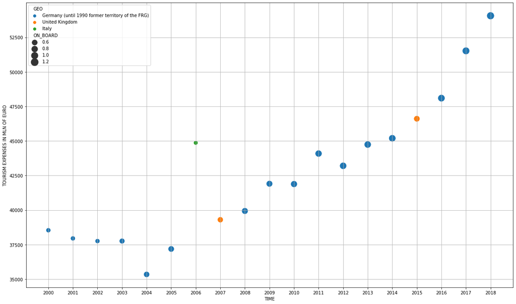

```python
#import seaborn as sns; sns.set()
import matplotlib.pyplot as plt
#sns.set_style("white")
plt.figure(figsize = (20,12))
ax = sns.scatterplot(x="TIME", y="Value", data=transportfirst_df,
                     hue="GEO", size="ON_BOARD",legend='brief',sizes=(100,300))
ax.set_xticks(transportfirst_df.TIME.values)
ax.set_ylabel('TOURISM EXPENSES IN MLN OF EURO')
ax.grid(False)
plt.grid(b=None)
```

## Data analysis

```
The line that best fit the transport expenses has equation equal to: y = 806 x - 1577662

The line that best fit the in/out flows has equation equal to: y = 4292749 x - 8533998164

Here is the linear prediction for the transport expenses of the first country and its relative flow
of passengers in 2030 :

Prediction of transport expenses : 59566 expressed in Mln of €
Prediction of in/out flow.       : 180282515
```

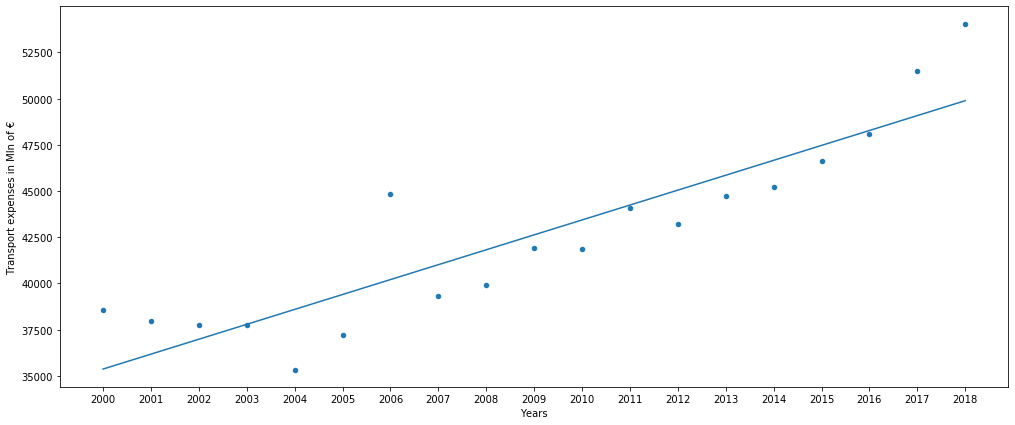

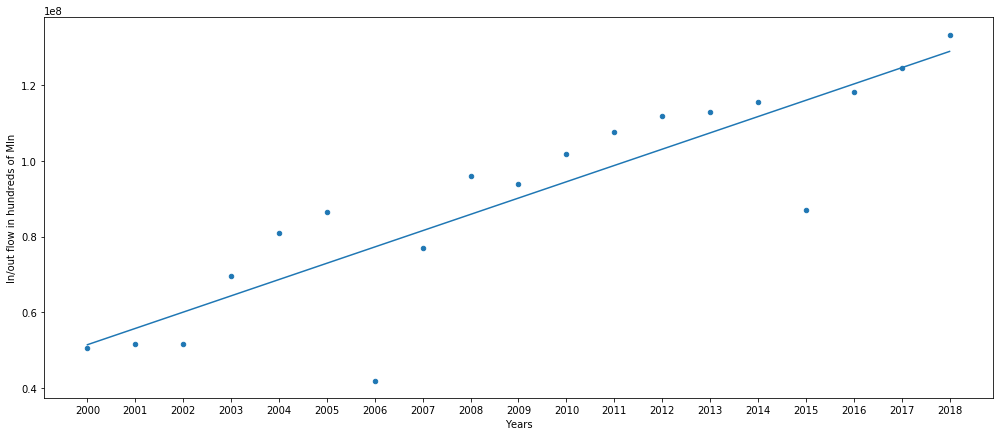

```python
from matplotlib.axes._axes import _log as matplotlib_axes_logger
matplotlib_axes_logger.setLevel('ERROR')
#sns.set_style("white")
exp_xs3 = transportfirst_df.TIME
exp_ys3 = transportfirst_df.Value
exp_trend3 = np.polyfit(exp_xs3,exp_ys3,deg=1)
transportfirst_df.plot.scatter(x='TIME',y='Value', figsize=(17,7), xticks=(list(transportfirst_df.TIME)))
exp_trendpoly3 = np.poly1d(exp_trend3)
plt.plot(exp_xs3,exp_trendpoly3(exp_xs3))
plt.ylabel('Transport expenses in Mln of €')
plt.xlabel('Years')

exp_predict3 = np.poly1d(exp_trend3)
to_be_predicted = 2030

matplotlib_axes_logger.setLevel('ERROR')
#sns.set_style("white")
flow_xs3 = transportfirst_df.TIME
flow_ys3 = transportfirst_df.ON_BOARD
flow_trend3 = np.polyfit(flow_xs3,flow_ys3,deg=1)
transportfirst_df.plot.scatter(x='TIME',y='ON_BOARD', figsize=(17,7), xticks=(list(transportfirst_df.TIME)))
flow_trendpoly3 = np.poly1d(flow_trend3)
plt.plot(flow_xs3,flow_trendpoly3(flow_xs3))
plt.ylabel('In/out flow in hundreds of Mln')
plt.xlabel('Years')
print("The line that best fit the transport expenses has equation equal to: y =",int(exp_trend3[0]),"x -",int(abs(exp_trend3[1])))
print()
print("The line that best fit the in/out flows has equation equal to: y =",int(flow_trend3[0]),"x -",int(abs(flow_trend3[1])))
flow_predict3 = np.poly1d(flow_trend3)
print()
print("Here is the linear prediction for the transport expenses of the first country and its relative flow")
print("of passengers in",to_be_predicted,":")
print()
print("Prediction of transport expenses :",  int(exp_predict3(to_be_predicted)), "expressed in Mln of €")
print("Prediction of in/out flow.       :", int(flow_predict3(to_be_predicted)))
```

```python
from sklearn.metrics import r2_score

exp_r_squared3 = r2_score(exp_ys3, exp_predict3(exp_xs3))
print("Let's test the accuracy of our model with the R-squared value.")
print()
print("The R-squared value of the transport expenses prediction is:", exp_r_squared3 )
print("meaning that we can be about",int(exp_r_squared3*100),"% confident that the prediction is right.")
print()
flow_r_squared3 = r2_score(flow_ys3, flow_predict3(flow_xs3))
print("The R-squared value of the flow prediction is:", flow_r_squared3 )
print("meaning that we can be about",int(flow_r_squared3*100),"% confident that the prediction is right.")
```

```
Let's test the accuracy of our model with the R-squared value.

The R-squared value of the transport expenses prediction is: 0.8023325340793769
meaning that we can be about 80 % confident that the prediction is right.

The R-squared value of the flow prediction is: 0.7810106797496428
meaning that we can be about 78 % confident that the prediction is right.
```

# INTERACTIVE PART

### If you run all, the execution stops *down here* because it waits for the user input

# Question 1

```python
to_be_predicted = int(input("What year you want to predict the number of arrivals of the most visited EU country? "))
print()
print("Prediction of number of arrivals in", to_be_predicted,":", int(predict1(to_be_predicted)))
```

```
What year you want to predict the number of arrivals of the most visited EU country? 2030

Prediction of number of arrivals in 2030 : 91292930
```

# Question 2A

```python
to_be_predicted = int(input("What year you want to predict the cultural expenses of the first country and its relative number of arrivals? "))
print()

print("Prediction of cultural expenses  in",to_be_predicted,":",  int(exp_predict2a(to_be_predicted)), "expressed in Mln of €")
print("Prediction of number of arrivals in",to_be_predicted,":", int(arr_predict2a(to_be_predicted)))
```

```
What year you want to predict the cultural expenses of the first country and its relative number of arrivals? 2030

Prediction of cultural expenses  in 2030 : 181203 expressed in Mln of €
Prediction of number of arrivals in 2030 : 83932996
```

# Question 2B

```python
to_be_predicted = int(input("What year you want to predict the cultural expenses of the first country and its relative number of departures? "))
print()
print("Prediction of cultural expenses    in", to_be_predicted,":",  int(exp_predict2b(to_be_predicted)), "expressed in Mln of €")
print("Prediction of number of departures in", to_be_predicted,":", int(dep_predict2b(to_be_predicted)))
```

```
What year you want to predict the cultural expenses of the first country and its relative number of departures? 2030

Prediction of cultural expenses    in 2030 : 181203 expressed in Mln of €
Prediction of number of departures in 2030 : 83671445
```

# Question 3

```python
to_be_predicted = int(input("What year you want to predict the transport expenses of the first country and its relative flow of passengers? "))
print()
print("Prediction of transport expenses in",to_be_predicted,":",  int(exp_predict3(to_be_predicted)), "expressed in Mln of €")
print("Prediction of in/out flow        in",to_be_predicted,":", int(flow_predict3(to_be_predicted)))
```

```
What year you want to predict the transport expenses of the first country and its relative flow of passengers? 2030

Prediction of transport expenses in 2030 : 59566 expressed in Mln of €
Prediction of in/out flow        in 2030 : 180282515
```